[figure not shown]

# **TRABAJO PRACTICO GRUPAL**

## **Comisión:** c24007

## **Grupo:** 123

## **Integrantes**

- Anabel Cecilia Rodriguez
- Roxana Pereyra
- Mara Ulla

## **Enunciado y fuente de datos**

[Enunciado](https://drive.google.com/file/d/1WkEN84E9gOp_wYbu1lzgL1hqFA3L5vOc/view)

Archivos:

- [sales_in_Paraguay.xlsx](https://docs.google.com/spreadsheets/d/1hsJkHRC3MbDBzVvyMR5sanmaEuI-wOIg/edit?gid=1667933102#gid=1667933102)
- [distributors_profiles.csv](https://drive.google.com/file/d/1tGc9vEOQ0pZa9J15jguN5dps9S78FaNH/view)
- [exports_to_Paraguay.csv](https://drive.google.com/file/d/1A1_lBKw7L9JInVrqN-HhalFjmxd1Pp3k/view)
- [locations_profiles.csv](https://drive.google.com/file/d/1HULr0Tt1sWmKaK9rjEirZKKt02yej-uD/view)

# **FUENTES DE DATOS**

## **Librerias utilizadas**

```python
from google.colab import drive
drive.mount('/content/drive')
```

```python
# Importación de librerias
import pandas as pd
import numpy as np
import matplotlib.pyplot as plt
import seaborn as sns
import matplotlib.ticker as mticker
from IPython.display import display, Markdown
```

```python
# Rutas a los archivos
sales_path = 'https://drive.google.com/uc?id=1pvyXE9ajjm84StcBDaPumFbgiGMEVKdZ'
locations_path = 'https://drive.google.com/uc?id=14zOiedLb0WZMgr4I5v9rFVKKJNyUeI-o'
export_path = 'https://drive.google.com/uc?id=1EflWeiHix8f3LlHdG88L2W1vKme84O_E'
distributor_path = 'https://drive.google.com/uc?id=11CXloLMsHhz8zRt_xRrS8rBGrSOu6hk9'
```

## **Archivo SALES_IN_PARAGUAY.xlsx**

### **Limpieza de datos**

```python
sales_df=pd.read_excel(sales_path)
```

```python
# Datos sin limpiar
sales_df
```

|  | distributor | Rubber | Brass | Vinyl | Granite | Stone | Brick | Aluminum | Glass | Plexiglass | Steel | Wood | Plastic |
| --- | --- | --- | --- | --- | --- | --- | --- | --- | --- | --- | --- | --- | --- |
| 0 | 583 | $54.510.203,61 | $45.268.636,86 | $51.579.748,25 | $21.780.180,58 | $26.576.776,52 | $0,00 | $55.872.547,77 | $18.050.385,12 | $178.927.599,01 | $2.788,80 | $54.510.203,61 | $20.982,80 |
| 1 | 1104 | $32.438.788,20 | $25.837.100,49 | $36.603.264,50 | $21.883.374,92 | $1.473.437,08 | $0,00 | $46.239.695,30 | $33.102.840,61 | $35.563.624,11 | $599,01 | $9.945.371,16 | $187.306,41 |
| 2 | 1384 | $21.780.180,58 | $78.927.599,01 | $25.837.100,49 | $33.102.840,61 | $51.579.748,25 | $0,00 | $21.883.374,92 | $78.927.599,01 | $1.346.769,34 | $0,00 | $36.603.264,50 | $300.838,58 |
| 3 | 379 | $79.358.855,35 | $90.185.311,22 | $45.268.636,86 | $54.510.203,61 | $59.358.855,35 | $0,00 | $79.358.855,35 | $32.067.534,68 | $53.172.624,14 | $2.922,94 | $33.102.840,61 | $579.748,25 |
| 4 | 1599 | $11.758.005,07 | $21.780.180,58 | $57.187.306,41 | $9.945.371,16 | $32.067.534,68 | $0,00 | $53.172.624,14 | $57.187.306,41 | $1.155.872.547,77 | $203,61 | $43.512.922,94 | $730.734,07 |
| 5 | 1062 | $90.185.311,22 | $43.512.922,94 | $11.758.005,07 | $76.443.998,86 | $36.999.867,09 | $23.012,00 | $51.673.437,08 | $61.236.075,66 | $165.978.582,24 | $840,61 | $27.179.878,86 | $780.180,58 |
| 6 | 1679 | $78.927.599,01 | $57.187.306,41 | $41.899.590,44 | $18.050.385,12 | $20.344.007,84 | $0,00 | $35.563.624,11 | $90.185.311,22 | $121.883.374,92 | $855,35 | $11.758.005,07 | $883.374,92 |
| 7 | 1302 | $5.662.736,92 | $59.862.809,01 | $46.239.695,30 | $90.185.311,22 | $36.603.264,50 | $0,00 | $81.812.951,32 | $57.009.912,25 | $42.411.396,23 | $6,86 | $35.563.624,11 | $899.590,44 |
| 8 | 565 | $57.009.912,25 | $53.172.624,14 | $36.999.867,09 | $59.199.680,31 | $78.927.599,01 | $12.548,00 | $42.411.396,23 | $55.872.547,77 | $25.837.100,49 | $82,23 | $22.300.838,58 | $1.346.769,34 |
| 9 | 860 | $36.603.264,50 | $54.510.203,61 | $1.346.769,34 | $18.421.797,13 | $10.536.882,23 | $0,00 | $21.780.180,58 | $11.758.005,07 | $11.758.005,07 | $7.306,41 | $76.443.998,86 | $1.473.437,08 |
| 10 | 707 | $59.199.680,31 | $59.199.680,31 | $9.945.371,16 | $55.872.547,77 | $43.512.922,94 | $11.452,00 | $26.576.776,52 | $18.421.797,13 | $1.221.780.180,58 | $3.374,92 | $25.837.100,49 | $7.874.267,01 |
| 11 | 846 | $61.236.075,66 | $32.067.534,68 | $21.883.374,92 | $53.172.624,14 | $59.199.680,31 | $0,00 | $33.102.840,61 | $25.837.100,49 | $118.050.385,12 | $76,52 | $57.009.912,25 | $9.945.371,16 |
| 12 | 175 | $26.576.776,52 | $22.300.838,58 | $1.473.437,08 | $41.572.788,80 | $65.978.582,24 | $0,00 | $41.899.590,44 | $21.883.374,92 | $161.236.075,66 | $437,08 | $16.662.942,92 | $11.758.005,07 |
| 13 | 241 | $59.862.809,01 | $55.020.982,80 | $78.927.599,01 | $55.020.982,80 | $54.510.203,61 | $0,00 | $28.421.797,13 | $46.239.695,30 | $55.020.982,80 | $951,32 | $53.172.624,14 | $12.466.621,84 |
| 14 | 1553 | $33.102.840,61 | $21.883.374,92 | $43.512.922,94 | $177.874.267,01 | $32.438.788,20 | $0,00 | $18.050.385,12 | $53.172.624,14 | $45.268.636,86 | $95,30 | $51.579.748,25 | $16.086.016,33 |
| 15 | 1093 | $1.346.769,34 | $16.086.016,33 | $65.978.582,24 | $12.466.621,84 | $11.758.005,07 | $0,00 | $36.603.264,50 | $76.473.998,86 | $1.126.662.942,92 | $78,86 | $59.862.809,01 | $18.050.385,12 |
| 16 | 1666 | $45.268.636,86 | $79.358.855,35 | $59.199.680,31 | $26.576.776,52 | $33.102.840,61 | $2.669,00 | $45.268.636,86 | $27.179.878,86 | $1.026.576.776,52 | $2.809,01 | $55.020.982,80 | $18.421.797,13 |
| 17 | 504 | $20.344.007,84 | $1.346.769,34 | $22.300.838,58 | $35.563.624,11 | $27.045.333,20 | $0,00 | $76.443.998,86 | $79.358.855,35 | $1.279.358.855,35 | $8.788,20 | $1.346.769,34 | $20.344.007,84 |
| 18 | 723 | $77.874.267,01 | $51.579.748,25 | $32.067.534,68 | $11.758.005,07 | $57.009.912,25 | $0,00 | $55.020.982,80 | $21.283.181,58 | $22.300.838,58 | $0,00 | $17.401.797,13 | $25.837.100,49 |
| 19 | 1723 | $42.411.396,23 | $57.009.912,25 | $90.185.311,22 | $57.187.306,41 | $77.874.267,01 | $0,00 | $54.510.203,61 | $20.344.007,84 | $41.572.788,80 | $180,58 | $32.067.534,68 | $26.576.776,52 |
| 20 | 920 | $10.536.882,23 | $27.179.878,86 | $79.358.855,35 | $27.009.912,25 | $57.187.306,41 | $0,00 | $90.185.311,22 | $65.978.582,24 | $1.159.822.809,01 | $267,01 | $10.473.437,08 | $27.179.878,86 |
| 21 | 1055 | $46.239.695,30 | $1.473.437,08 | $41.572.788,80 | $61.236.075,66 | $5.662.736,92 | $0,00 | $59.945.371,16 | $45.268.636,86 | $36.603.264,50 | $99,44 | $45.268.636,86 | $32.067.534,68 |
| 22 | 815 | $51.579.748,25 | $46.239.695,30 | $53.172.624,14 | $27.179.878,86 | $25.837.100,49 | $0,00 | $43.512.922,94 | $12.466.621,84 | $57.187.306,41 | $838,58 | $12.466.621,84 | $33.102.840,61 |
| 23 | 161 | $41.572.788,80 | $35.563.624,11 | $27.179.878,86 | $79.358.855,35 | $1.346.769,34 | $13.455,00 | $27.179.878,86 | $154.510.203,61 | $43.512.922,94 | $534,68 | $59.199.680,31 | $35.563.624,11 |
| 24 | 378 | $16.086.016,33 | $11.812.951,32 | $18.050.385,12 | $51.579.748,25 | $21.780.180,58 | $0,00 | $21.344.007,84 | $41.572.788,80 | $151.579.748,25 | $2.547,77 | $18.050.385,12 | $36.603.264,50 |
| 25 | 1235 | $35.563.624,11 | $42.411.396,23 | $81.812.951,32 | $65.978.582,24 | $90.185.311,22 | $0,00 | $41.572.788,80 | $6.662.942,92 | $5.441.399.590,44 | $0,00 | $79.358.855,35 | $36.999.867,09 |
| 26 | 1017 | $22.300.838,58 | $61.236.075,66 | $61.236.075,66 | $36.059.867,09 | $61.236.075,66 | $0,00 | $11.758.005,07 | $2.487.198,27 | $1.246.239.695,30 | $0,00 | $41.899.590,44 | $41.572.788,80 |
| 27 | 1463 | $21.883.374,92 | $18.050.385,12 | $59.862.809,01 | $25.837.100,49 | $9.945.371,16 | $34.521,00 | $32.067.534,68 | $36.999.867,09 | $240.473.437,08 | $0,00 | $65.978.522,24 | $42.411.396,23 |
| 28 | 364 | $53.172.624,14 | $33.102.840,61 | $177.874.267,01 | $81.812.951,32 | $42.411.396,23 | $0,00 | $6.706.393,21 | $59.862.809,01 | $1.276.443.998,86 | $96,23 | $177.874.267,01 | $43.500.922,94 |
| 29 | 1710 | $41.899.599,44 | $55.872.547,77 | $26.576.776,52 | $41.899.590,44 | $55.072.547,77 | $0,00 | $59.199.680,31 | $96.603.264,50 | $1.081.812.951,32 | $736,92 | $57.187.306,41 | $45.268.636,86 |
| 30 | 1526 | $32.067.534,68 | $65.978.582,24 | $16.086.016,33 | $36.603.264,50 | $53.172.624,14 | $0,00 | $65.978.582,24 | $41.899.590,44 | $754.510.203,61 | $385,12 | $61.236.075,66 | $46.239.695,30 |
| 31 | 234 | $11.812.951,32 | $11.758.005,07 | $18.421.797,13 | $43.512.922,94 | $16.086.016,33 | $0,00 | $21.346.769,34 | $42.411.396,23 | $1.159.199.680,31 | $0,00 | $42.411.396,23 | $53.172.624,14 |
| 32 | 1560 | $57.187.306,41 | $177.874.267,01 | $54.510.203,61 | $32.067.534,68 | $3.221.765,13 | $0,00 | $78.927.599,01 | $1.586.769,34 | $16.086.016,33 | $0,00 | $20.344.007,84 | $54.510.203,61 |
| 33 | 1489 | $1.473.437,08 | $76.443.998,86 | $42.411.396,23 | $22.300.838,58 | $46.239.695,30 | $0,00 | $157.187.306,41 | $16.086.016,33 | $18.421.797,13 | $0,00 | $78.927.599,01 | $55.872.547,77 |
| 34 | 1183 | $55.020.982,80 | $9.945.371,16 | $20.344.007,84 | $41.927.599,01 | $41.899.599,44 | $0,00 | $36.999.867,09 | $81.812.951,32 | $90.185.311,22 | $11.121,98 | $16.086.016,33 | $61.236.075,66 |
| 35 | 308 | $18.050.385,12 | $41.899.590,44 | $33.102.840,61 | $20.344.007,84 | $45.268.636,86 | $0,00 | $177.874.267,01 | $26.576.776,52 | $1.227.171.427,00 | $25,61 | $41.570.788,80 | $65.862.809,01 |
| 36 | 1418 | $27.179.878,86 | $36.999.867,09 | $55.872.547,77 | $1.346.769,34 | $35.563.624,11 | $0,00 | $25.837.100,49 | $35.563.624,11 | $2.536.999.867,09 | $0,00 | $55.872.547,77 | $65.978.582,24 |
| 37 | 818 | $25.837.100,49 | $26.576.776,52 | $21.780.180,58 | $6.662.942,92 | $51.862.809,01 | $12.543,00 | $36.086.016,33 | $55.020.982,80 | $20.344.007,84 | $4.703,51 | $26.576.776,52 | $79.358.855,35 |
| 38 | 619 | $43.512.922,94 | $20.344.007,84 | $55.020.982,80 | $42.411.396,23 | $11.812.951,32 | $0,00 | $59.862.809,01 | $51.579.748,25 | $32.067.534,68 | $982,80 | $46.239.695,30 | $81.812.951,32 |
| 39 | 715 | $9.945.371,16 | $41.572.788,80 | $6.662.942,92 | $1.473.437,08 | $55.020.982,80 | $0,00 | $61.236.075,66 | $43.512.922,94 | $1.033.102.840,61 | $0,00 | $21.883.374,92 | $100.443.998,86 |
| 40 | 808 | $3.221.765,13 | $10.536.882,23 | $35.563.624,11 | $46.039.695,30 | $22.300.838,58 | $0,00 | $51.579.748,25 | $59.199.680,31 | $12.466.621,84 | $80,31 | $36.999.867,09 | $112.927.599,01 |
| 41 | 325 | $36.999.867,09 | $6.662.942,92 | $76.443.998,86 | $45.268.636,86 | $18.050.385,12 | $0,00 | $22.300.838,58 | $122.200.838,58 | $50.009.912,25 | $0,00 | $21.780.180,58 | $152.239.912,25 |
| 42 | 1169 | $55.872.547,77 | $18.421.797,13 | $12.466.621,84 | $59.862.809,01 | $21.883.374,92 | $0,00 | $57.009.912,25 | $177.874.267,01 | $1.219.945.371,16 | $3.640,40 | $81.810.951,20 | $243.662.942,92 |
| 43 | 29 | $65.978.582,24 | $36.603.264,50 | $57.009.912,25 | $16.931.446,04 | $41.572.788,80 | $42.458,00 | $12.466.621,84 | $9.945.371,16 | $177.874.267,01 | $0,00 | $90.185.311,22 | $325.185.311,22 |
| 44 | total | $1.680.453.941,34 | $1.840.659.381,00 | $1.912.589.120,61 | $1.845.294.550,32 | $1.651.519.395,68 | $152.658,00 | $2.163.832.570,90 | $2.173.275.882,80 | $25.974.040.668,75 | $58.458,00 | $1.930.565.060,49 | $2.047.338.174,36 |

```python
# Columnas
print(sales_df.columns)
print("================================================================================")
# Filas
print(sales_df.index)
```

```
Index(['distributor', 'Rubber', 'Brass', 'Vinyl', 'Granite', 'Stone', 'Brick',
       'Aluminum', 'Glass', 'Plexiglass', 'Steel', 'Wood', 'Plastic'],
      dtype='object')
================================================================================
RangeIndex(start=0, stop=45, step=1)
```

```python
# Eliminación de la última fila.
sales_df = sales_df.drop(sales_df.index[-1])
```

```python
# Tipo de datos
sales_df.head()
sales_df.dtypes
```

```
distributor    object
Rubber         object
Brass          object
Vinyl          object
Granite        object
Stone          object
Brick          object
Aluminum       object
Glass          object
Plexiglass     object
Steel          object
Wood           object
Plastic        object
dtype: object
```

```python
# Modificación de los caracteres "$" y "."
for columna in sales_df.columns[1:13]:
  sales_df[columna]=sales_df[columna].str.replace('$', '')
  sales_df[columna]=sales_df[columna].str.replace('.', '')
  sales_df[columna]=sales_df[columna].str.replace(',', '.')

# Opcional: sales_df=sales_df.apply(lambda x: x.str.replace(',', '.'),axis=1,if x.dtype == "object" else x)
```

```python
# Transformación de tipo de dato de todas las columnas excepto "distribuidor"
for col in sales_df.columns[1:]:
  sales_df[col] = sales_df[col].astype(float)
```

```python
# Transformación del tipo de dato de la columna "distributor"
sales_df['distributor'] = sales_df['distributor'].astype(int)
```

```python
# Renombrar la columna "distributor"
sales_df= sales_df.rename(columns={'distributor': 'distributor_id'})
```

```python
# Confirmación de la transformación del tipo de datos con los cambios efectuados
sales_df.head()
sales_df.dtypes
```

```
distributor_id      int64
Rubber            float64
Brass             float64
Vinyl             float64
Granite           float64
Stone             float64
Brick             float64
Aluminum          float64
Glass             float64
Plexiglass        float64
Steel             float64
Wood              float64
Plastic           float64
dtype: object
```

### **Datos limpios**

```python
sales_df
```

|  | distributor_id | Rubber | Brass | Vinyl | Granite | Stone | Brick | Aluminum | Glass | Plexiglass | Steel | Wood | Plastic |
| --- | --- | --- | --- | --- | --- | --- | --- | --- | --- | --- | --- | --- | --- |
| 0 | 583 | 54510203.61 | 4.526864e+07 | 5.157975e+07 | 2.178018e+07 | 26576776.52 | 0.0 | 5.587255e+07 | 1.805039e+07 | 1.789276e+08 | 2788.80 | 5.451020e+07 | 2.098280e+04 |
| 1 | 1104 | 32438788.20 | 2.583710e+07 | 3.660326e+07 | 2.188337e+07 | 1473437.08 | 0.0 | 4.623970e+07 | 3.310284e+07 | 3.556362e+07 | 599.01 | 9.945371e+06 | 1.873064e+05 |
| 2 | 1384 | 21780180.58 | 7.892760e+07 | 2.583710e+07 | 3.310284e+07 | 51579748.25 | 0.0 | 2.188337e+07 | 7.892760e+07 | 1.346769e+06 | 0.00 | 3.660326e+07 | 3.008386e+05 |
| 3 | 379 | 79358855.35 | 9.018531e+07 | 4.526864e+07 | 5.451020e+07 | 59358855.35 | 0.0 | 7.935886e+07 | 3.206753e+07 | 5.317262e+07 | 2922.94 | 3.310284e+07 | 5.797482e+05 |
| 4 | 1599 | 11758005.07 | 2.178018e+07 | 5.718731e+07 | 9.945371e+06 | 32067534.68 | 0.0 | 5.317262e+07 | 5.718731e+07 | 1.155873e+09 | 203.61 | 4.351292e+07 | 7.307341e+05 |
| 5 | 1062 | 90185311.22 | 4.351292e+07 | 1.175801e+07 | 7.644400e+07 | 36999867.09 | 23012.0 | 5.167344e+07 | 6.123608e+07 | 1.659786e+08 | 840.61 | 2.717988e+07 | 7.801806e+05 |
| 6 | 1679 | 78927599.01 | 5.718731e+07 | 4.189959e+07 | 1.805039e+07 | 20344007.84 | 0.0 | 3.556362e+07 | 9.018531e+07 | 1.218834e+08 | 855.35 | 1.175801e+07 | 8.833749e+05 |
| 7 | 1302 | 5662736.92 | 5.986281e+07 | 4.623970e+07 | 9.018531e+07 | 36603264.50 | 0.0 | 8.181295e+07 | 5.700991e+07 | 4.241140e+07 | 6.86 | 3.556362e+07 | 8.995904e+05 |
| 8 | 565 | 57009912.25 | 5.317262e+07 | 3.699987e+07 | 5.919968e+07 | 78927599.01 | 12548.0 | 4.241140e+07 | 5.587255e+07 | 2.583710e+07 | 82.23 | 2.230084e+07 | 1.346769e+06 |
| 9 | 860 | 36603264.50 | 5.451020e+07 | 1.346769e+06 | 1.842180e+07 | 10536882.23 | 0.0 | 2.178018e+07 | 1.175801e+07 | 1.175801e+07 | 7306.41 | 7.644400e+07 | 1.473437e+06 |
| 10 | 707 | 59199680.31 | 5.919968e+07 | 9.945371e+06 | 5.587255e+07 | 43512922.94 | 11452.0 | 2.657678e+07 | 1.842180e+07 | 1.221780e+09 | 3374.92 | 2.583710e+07 | 7.874267e+06 |
| 11 | 846 | 61236075.66 | 3.206753e+07 | 2.188337e+07 | 5.317262e+07 | 59199680.31 | 0.0 | 3.310284e+07 | 2.583710e+07 | 1.180504e+08 | 76.52 | 5.700991e+07 | 9.945371e+06 |
| 12 | 175 | 26576776.52 | 2.230084e+07 | 1.473437e+06 | 4.157279e+07 | 65978582.24 | 0.0 | 4.189959e+07 | 2.188337e+07 | 1.612361e+08 | 437.08 | 1.666294e+07 | 1.175801e+07 |
| 13 | 241 | 59862809.01 | 5.502098e+07 | 7.892760e+07 | 5.502098e+07 | 54510203.61 | 0.0 | 2.842180e+07 | 4.623970e+07 | 5.502098e+07 | 951.32 | 5.317262e+07 | 1.246662e+07 |
| 14 | 1553 | 33102840.61 | 2.188337e+07 | 4.351292e+07 | 1.778743e+08 | 32438788.20 | 0.0 | 1.805039e+07 | 5.317262e+07 | 4.526864e+07 | 95.30 | 5.157975e+07 | 1.608602e+07 |
| 15 | 1093 | 1346769.34 | 1.608602e+07 | 6.597858e+07 | 1.246662e+07 | 11758005.07 | 0.0 | 3.660326e+07 | 7.647400e+07 | 1.126663e+09 | 78.86 | 5.986281e+07 | 1.805039e+07 |
| 16 | 1666 | 45268636.86 | 7.935886e+07 | 5.919968e+07 | 2.657678e+07 | 33102840.61 | 2669.0 | 4.526864e+07 | 2.717988e+07 | 1.026577e+09 | 2809.01 | 5.502098e+07 | 1.842180e+07 |
| 17 | 504 | 20344007.84 | 1.346769e+06 | 2.230084e+07 | 3.556362e+07 | 27045333.20 | 0.0 | 7.644400e+07 | 7.935886e+07 | 1.279359e+09 | 8788.20 | 1.346769e+06 | 2.034401e+07 |
| 18 | 723 | 77874267.01 | 5.157975e+07 | 3.206753e+07 | 1.175801e+07 | 57009912.25 | 0.0 | 5.502098e+07 | 2.128318e+07 | 2.230084e+07 | 0.00 | 1.740180e+07 | 2.583710e+07 |
| 19 | 1723 | 42411396.23 | 5.700991e+07 | 9.018531e+07 | 5.718731e+07 | 77874267.01 | 0.0 | 5.451020e+07 | 2.034401e+07 | 4.157279e+07 | 180.58 | 3.206753e+07 | 2.657678e+07 |
| 20 | 920 | 10536882.23 | 2.717988e+07 | 7.935886e+07 | 2.700991e+07 | 57187306.41 | 0.0 | 9.018531e+07 | 6.597858e+07 | 1.159823e+09 | 267.01 | 1.047344e+07 | 2.717988e+07 |
| 21 | 1055 | 46239695.30 | 1.473437e+06 | 4.157279e+07 | 6.123608e+07 | 5662736.92 | 0.0 | 5.994537e+07 | 4.526864e+07 | 3.660326e+07 | 99.44 | 4.526864e+07 | 3.206753e+07 |
| 22 | 815 | 51579748.25 | 4.623970e+07 | 5.317262e+07 | 2.717988e+07 | 25837100.49 | 0.0 | 4.351292e+07 | 1.246662e+07 | 5.718731e+07 | 838.58 | 1.246662e+07 | 3.310284e+07 |
| 23 | 161 | 41572788.80 | 3.556362e+07 | 2.717988e+07 | 7.935886e+07 | 1346769.34 | 13455.0 | 2.717988e+07 | 1.545102e+08 | 4.351292e+07 | 534.68 | 5.919968e+07 | 3.556362e+07 |
| 24 | 378 | 16086016.33 | 1.181295e+07 | 1.805039e+07 | 5.157975e+07 | 21780180.58 | 0.0 | 2.134401e+07 | 4.157279e+07 | 1.515797e+08 | 2547.77 | 1.805039e+07 | 3.660326e+07 |
| 25 | 1235 | 35563624.11 | 4.241140e+07 | 8.181295e+07 | 6.597858e+07 | 90185311.22 | 0.0 | 4.157279e+07 | 6.662943e+06 | 5.441400e+09 | 0.00 | 7.935886e+07 | 3.699987e+07 |
| 26 | 1017 | 22300838.58 | 6.123608e+07 | 6.123608e+07 | 3.605987e+07 | 61236075.66 | 0.0 | 1.175801e+07 | 2.487198e+06 | 1.246240e+09 | 0.00 | 4.189959e+07 | 4.157279e+07 |
| 27 | 1463 | 21883374.92 | 1.805039e+07 | 5.986281e+07 | 2.583710e+07 | 9945371.16 | 34521.0 | 3.206753e+07 | 3.699987e+07 | 2.404734e+08 | 0.00 | 6.597852e+07 | 4.241140e+07 |
| 28 | 364 | 53172624.14 | 3.310284e+07 | 1.778743e+08 | 8.181295e+07 | 42411396.23 | 0.0 | 6.706393e+06 | 5.986281e+07 | 1.276444e+09 | 96.23 | 1.778743e+08 | 4.350092e+07 |
| 29 | 1710 | 41899599.44 | 5.587255e+07 | 2.657678e+07 | 4.189959e+07 | 55072547.77 | 0.0 | 5.919968e+07 | 9.660326e+07 | 1.081813e+09 | 736.92 | 5.718731e+07 | 4.526864e+07 |
| 30 | 1526 | 32067534.68 | 6.597858e+07 | 1.608602e+07 | 3.660326e+07 | 53172624.14 | 0.0 | 6.597858e+07 | 4.189959e+07 | 7.545102e+08 | 385.12 | 6.123608e+07 | 4.623970e+07 |
| 31 | 234 | 11812951.32 | 1.175801e+07 | 1.842180e+07 | 4.351292e+07 | 16086016.33 | 0.0 | 2.134677e+07 | 4.241140e+07 | 1.159200e+09 | 0.00 | 4.241140e+07 | 5.317262e+07 |
| 32 | 1560 | 57187306.41 | 1.778743e+08 | 5.451020e+07 | 3.206753e+07 | 3221765.13 | 0.0 | 7.892760e+07 | 1.586769e+06 | 1.608602e+07 | 0.00 | 2.034401e+07 | 5.451020e+07 |
| 33 | 1489 | 1473437.08 | 7.644400e+07 | 4.241140e+07 | 2.230084e+07 | 46239695.30 | 0.0 | 1.571873e+08 | 1.608602e+07 | 1.842180e+07 | 0.00 | 7.892760e+07 | 5.587255e+07 |
| 34 | 1183 | 55020982.80 | 9.945371e+06 | 2.034401e+07 | 4.192760e+07 | 41899599.44 | 0.0 | 3.699987e+07 | 8.181295e+07 | 9.018531e+07 | 11121.98 | 1.608602e+07 | 6.123608e+07 |
| 35 | 308 | 18050385.12 | 4.189959e+07 | 3.310284e+07 | 2.034401e+07 | 45268636.86 | 0.0 | 1.778743e+08 | 2.657678e+07 | 1.227171e+09 | 25.61 | 4.157079e+07 | 6.586281e+07 |
| 36 | 1418 | 27179878.86 | 3.699987e+07 | 5.587255e+07 | 1.346769e+06 | 35563624.11 | 0.0 | 2.583710e+07 | 3.556362e+07 | 2.537000e+09 | 0.00 | 5.587255e+07 | 6.597858e+07 |
| 37 | 818 | 25837100.49 | 2.657678e+07 | 2.178018e+07 | 6.662943e+06 | 51862809.01 | 12543.0 | 3.608602e+07 | 5.502098e+07 | 2.034401e+07 | 4703.51 | 2.657678e+07 | 7.935886e+07 |
| 38 | 619 | 43512922.94 | 2.034401e+07 | 5.502098e+07 | 4.241140e+07 | 11812951.32 | 0.0 | 5.986281e+07 | 5.157975e+07 | 3.206753e+07 | 982.80 | 4.623970e+07 | 8.181295e+07 |
| 39 | 715 | 9945371.16 | 4.157279e+07 | 6.662943e+06 | 1.473437e+06 | 55020982.80 | 0.0 | 6.123608e+07 | 4.351292e+07 | 1.033103e+09 | 0.00 | 2.188337e+07 | 1.004440e+08 |
| 40 | 808 | 3221765.13 | 1.053688e+07 | 3.556362e+07 | 4.603970e+07 | 22300838.58 | 0.0 | 5.157975e+07 | 5.919968e+07 | 1.246662e+07 | 80.31 | 3.699987e+07 | 1.129276e+08 |
| 41 | 325 | 36999867.09 | 6.662943e+06 | 7.644400e+07 | 4.526864e+07 | 18050385.12 | 0.0 | 2.230084e+07 | 1.222008e+08 | 5.000991e+07 | 0.00 | 2.178018e+07 | 1.522399e+08 |
| 42 | 1169 | 55872547.77 | 1.842180e+07 | 1.246662e+07 | 5.986281e+07 | 21883374.92 | 0.0 | 5.700991e+07 | 1.778743e+08 | 1.219945e+09 | 3640.40 | 8.181095e+07 | 2.436629e+08 |
| 43 | 29 | 65978582.24 | 3.660326e+07 | 5.700991e+07 | 1.693145e+07 | 41572788.80 | 42458.0 | 1.246662e+07 | 9.945371e+06 | 1.778743e+08 | 0.00 | 9.018531e+07 | 3.251853e+08 |

### **Datos estadísticos**

```python
# Datos estadísticos
sales_df.describe().round(2)
```

|  | distributor_id | Rubber | Brass | Vinyl | Granite | Stone | Brick | Aluminum | Glass | Plexiglass | Steel | Wood | Plastic |
| --- | --- | --- | --- | --- | --- | --- | --- | --- | --- | --- | --- | --- | --- |
| count | 44.00 | 44.00 | 4.400000e+01 | 4.400000e+01 | 4.400000e+01 | 44.00 | 44.0 | 4.400000e+01 | 4.400000e+01 | 4.400000e+01 | 44.00 | 4.400000e+01 | 4.400000e+01 |
| mean | 933.34 | 38192135.03 | 4.183317e+07 | 4.346793e+07 | 4.193851e+07 | 37534531.72 | 3469.5 | 4.917801e+07 | 4.939263e+07 | 5.903191e+08 | 1328.59 | 4.387648e+07 | 4.653041e+07 |
| std | 500.12 | 22861617.98 | 3.063711e+07 | 3.081215e+07 | 3.031603e+07 | 22046995.00 | 9185.9 | 3.311538e+07 | 3.733389e+07 | 9.576329e+08 | 2458.28 | 3.033049e+07 | 6.284744e+07 |
| min | 29.00 | 1346769.34 | 1.346769e+06 | 1.346769e+06 | 1.346769e+06 | 1346769.34 | 0.0 | 6.706393e+06 | 1.586769e+06 | 1.346769e+06 | 0.00 | 1.346769e+06 | 2.098280e+04 |
| 25% | 549.75 | 21421137.40 | 2.142114e+07 | 2.185758e+07 | 2.185758e+07 | 21421137.40 | 0.0 | 2.702910e+07 | 2.173333e+07 | 4.033041e+07 | 0.00 | 2.185758e+07 | 9.427595e+06 |
| 50% | 890.00 | 36801565.80 | 3.928633e+07 | 4.173619e+07 | 3.908803e+07 | 36801565.80 | 0.0 | 4.296216e+07 | 4.296216e+07 | 1.367316e+08 | 192.10 | 4.173519e+07 | 3.258519e+07 |
| 75% | 1392.50 | 55233874.04 | 5.615689e+07 | 5.705426e+07 | 5.523387e+07 | 54637898.41 | 0.0 | 5.936546e+07 | 6.020613e+07 | 1.133965e+09 | 959.19 | 5.705426e+07 | 5.485079e+07 |
| max | 1723.00 | 90185311.22 | 1.778743e+08 | 1.778743e+08 | 1.778743e+08 | 90185311.22 | 42458.0 | 1.778743e+08 | 1.778743e+08 | 5.441400e+09 | 11121.98 | 1.778743e+08 | 3.251853e+08 |

## **Archivo DISTRIBUTORS_PROFILES.csv**

### **Limpieza de datos**

```python
distributors_df=pd.read_csv(distributor_path)
```

```python
# Datos sin limpiar
distributors_df
```

|  | id | distributor | distributor activities | years in the construction market |
| --- | --- | --- | --- | --- |
| 0 | 565.000 | Abernathy-Hayes | construction materials import/distribution, ir... | 15 |
| 1 | 1.384 | Balistreri LLC | construction materials import/distribution, si... | 22 |
| 2 | 1.183 | Brekke-Stiedemann | construction materials import/distribution | 13 |
| 3 | 1.526 | Collins LLC | construction materials import/distribution | 12 |
| 4 | 29.000 | Cummings-Ward | construction materials import/distribution, ir... | 23 |
| 5 | 1.055 | Cummings, Kemmer and Walker | construction materials import/distribution, co... | 23 |
| 6 | 1.093 | Davis, Kiehn and Heller | construction materials import/distribution, ne... | 12 |
| 7 | 920.000 | Denesik, Schmidt and Wyman | construction materials import/distribution, zi... | 18 |
| 8 | 1.062 | Feil, MacGyver and Schamberger | construction materials import/distribution, \n... | 20 |
| 9 | NaN | NaN | NaN | 0 |
| 10 | 379.000 | Gerlach Group | construction materials import/distribution, el... | 2 |
| 11 | 1.489 | Goldner Inc | construction materials import/distribution, in... | 18 |
| 12 | 818.000 | Grady, Kessler and Stokes | construction materials import/distribution | 16 |
| 13 | 707.000 | Haley-Larson | construction materials import/distribution | 14 |
| 14 | 504.000 | Herman, Turcotte and Osinski | construction materials import/distribution, ce... | 16 |
| 15 | 715.000 | Keebler, Deckow and Watsica | construction materials import/distribution | 8 |
| 16 | 619.000 | Kerluke, Barrows and Murazik | construction materials import/distribution, as... | 19 |
| 17 | 846.000 | Kertzmann-Nolan | construction materials import/distribution, zi... | 15 |
| 18 | 860.000 | Kling Group | construction materials import/distribution, in... | 20 |
| 19 | 241.000 | Koch, Lang and Mertz | construction materials import/distribution, po... | 12 |
| 20 | 234.000 | Koepp, Hessel and Runolfsson | construction materials import/distribution | 15 |
| 21 | 1.463 | Kreiger, Leffler and Dibbert | construction materials import/distribution | 15 |
| 22 | 583.000 | Kulas-Terry | construction materials import/distribution, co... | 19 |
| 23 | 1.104 | Langworth Group | construction materials import/distribution, ne... | 22 |
| 24 | 175.000 | Legros Group | construction materials import/distribution, st... | 23 |
| 25 | 1.710 | Lesch, Reinger and Russel | construction materials import/distribution, in... | 13 |
| 26 | 161.000 | Maggio-Prohaska | construction materials import/distribution, ne... | 20 |
| 27 | 325.000 | Marks Inc | construction materials import/distribution | 19 |
| 28 | 1.666 | Marks, Walker and Streich | construction materials import/distribution, ce... | 25 |
| 29 | 1.553 | Mraz Group | construction materials import/distribution, br... | 15 |
| 30 | 1.302 | O'Reilly, Weber and Larkin | construction materials import/distribution | 13 |
| 31 | 364.000 | Okuneva, Simonis and Hintz | construction materials import/distribution | 24 |
| 32 | NaN | NaN | NaN | 0 |
| 33 | 1.599 | Orn-Bogan | construction materials import/distribution, co... | 17 |
| 34 | 308.000 | Reichel and Sons | construction materials import/distribution | 16 |
| 35 | 808.000 | Reilly, Hickle and Thiel | construction materials import/distribution, ne... | 18 |
| 36 | 1.017 | Rosenbaum LLC | construction materials import/distribution | 17 |
| 37 | 815.000 | Schamberger and Sons | construction materials import/distribution, co... | 8 |
| 38 | 378.000 | Schiller-Bartoletti | construction materials import/distribution | 17 |
| 39 | 1.723 | Sipes and Sons | construction materials import/distribution, co... | 23 |
| 40 | 723.000 | Stehr-Mitchell | construction materials import/distribution | 9 |
| 41 | 1.418 | Tremblay Group | construction materials import/distribution, br... | 17 |
| 42 | 1.235 | Tromp-Abshire | construction materials import/distribution, as... | 19 |
| 43 | 1.560 | Volkman-Goyette | construction materials import/distribution, in... | 18 |
| 44 | 1.169 | Williamson, Bailey and McLaughlin | construction materials import/distribution | 12 |
| 45 | 1.679 | Windler-Baumbach | construction materials import/distribution, st... | 15 |

```python
# Columnas
print(distributors_df.columns)
print("======================================================")
# Filas
print(distributors_df.index)
```

```
Index(['id', 'distributor', 'distributor activities',
       'years in the construction market'],
      dtype='object')
======================================================
RangeIndex(start=0, stop=46, step=1)
```

```python
# Eliminación de datos nulos
distributors_df.replace('#N/A', np.nan, inplace=True)
distributors_df.dropna(inplace=True)
```

```python
# Análisis de la existencia de duplicados. Resultado esperado: true/false
hay_duplicados_dist = distributors_df.duplicated().any()
print(f'\n¿Existen filas duplicadas', hay_duplicados_dist)
```

```
¿Existen filas duplicadas False
```

```python
# Modificación y eliminación de caracteres ("0",".",",") de la columna "id" y cambio del tipo de dato
distributors_df['id'] = distributors_df['id'].astype(str)
distributors_df["id"] = distributors_df["id"].str.replace('.0', '')
distributors_df["id"] = distributors_df["id"].str.replace('.00', '')
distributors_df["id"] = distributors_df["id"].str.replace('.000', '')
distributors_df["id"] = distributors_df["id"].str.replace('.', '')
distributors_df['id'] = distributors_df['id'].astype(int)
```

```python
# Renombrar la columna "id"
distributors_df= distributors_df.rename(columns={'id': 'distributor_id'})
```

```python
# Tipo de datos
distributors_df.head()
distributors_df.dtypes
```

```
distributor_id                       int64
distributor                         object
distributor activities              object
years in the construction market     int64
dtype: object
```

### **Datos limpios**

```python
distributors_df
```

|  | distributor_id | distributor | distributor activities | years in the construction market |
| --- | --- | --- | --- | --- |
| 0 | 565 | Abernathy-Hayes | construction materials import/distribution, ir... | 15 |
| 1 | 1384 | Balistreri LLC | construction materials import/distribution, si... | 22 |
| 2 | 1183 | Brekke-Stiedemann | construction materials import/distribution | 13 |
| 3 | 1526 | Collins LLC | construction materials import/distribution | 12 |
| 4 | 29 | Cummings-Ward | construction materials import/distribution, ir... | 23 |
| 5 | 155 | Cummings, Kemmer and Walker | construction materials import/distribution, co... | 23 |
| 6 | 193 | Davis, Kiehn and Heller | construction materials import/distribution, ne... | 12 |
| 7 | 920 | Denesik, Schmidt and Wyman | construction materials import/distribution, zi... | 18 |
| 8 | 162 | Feil, MacGyver and Schamberger | construction materials import/distribution, \n... | 20 |
| 10 | 379 | Gerlach Group | construction materials import/distribution, el... | 2 |
| 11 | 1489 | Goldner Inc | construction materials import/distribution, in... | 18 |
| 12 | 818 | Grady, Kessler and Stokes | construction materials import/distribution | 16 |
| 13 | 707 | Haley-Larson | construction materials import/distribution | 14 |
| 14 | 504 | Herman, Turcotte and Osinski | construction materials import/distribution, ce... | 16 |
| 15 | 715 | Keebler, Deckow and Watsica | construction materials import/distribution | 8 |
| 16 | 619 | Kerluke, Barrows and Murazik | construction materials import/distribution, as... | 19 |
| 17 | 846 | Kertzmann-Nolan | construction materials import/distribution, zi... | 15 |
| 18 | 860 | Kling Group | construction materials import/distribution, in... | 20 |
| 19 | 241 | Koch, Lang and Mertz | construction materials import/distribution, po... | 12 |
| 20 | 234 | Koepp, Hessel and Runolfsson | construction materials import/distribution | 15 |
| 21 | 1463 | Kreiger, Leffler and Dibbert | construction materials import/distribution | 15 |
| 22 | 583 | Kulas-Terry | construction materials import/distribution, co... | 19 |
| 23 | 1104 | Langworth Group | construction materials import/distribution, ne... | 22 |
| 24 | 175 | Legros Group | construction materials import/distribution, st... | 23 |
| 25 | 171 | Lesch, Reinger and Russel | construction materials import/distribution, in... | 13 |
| 26 | 161 | Maggio-Prohaska | construction materials import/distribution, ne... | 20 |
| 27 | 325 | Marks Inc | construction materials import/distribution | 19 |
| 28 | 1666 | Marks, Walker and Streich | construction materials import/distribution, ce... | 25 |
| 29 | 1553 | Mraz Group | construction materials import/distribution, br... | 15 |
| 30 | 1302 | O'Reilly, Weber and Larkin | construction materials import/distribution | 13 |
| 31 | 364 | Okuneva, Simonis and Hintz | construction materials import/distribution | 24 |
| 33 | 1599 | Orn-Bogan | construction materials import/distribution, co... | 17 |
| 34 | 308 | Reichel and Sons | construction materials import/distribution | 16 |
| 35 | 808 | Reilly, Hickle and Thiel | construction materials import/distribution, ne... | 18 |
| 36 | 117 | Rosenbaum LLC | construction materials import/distribution | 17 |
| 37 | 815 | Schamberger and Sons | construction materials import/distribution, co... | 8 |
| 38 | 378 | Schiller-Bartoletti | construction materials import/distribution | 17 |
| 39 | 1723 | Sipes and Sons | construction materials import/distribution, co... | 23 |
| 40 | 723 | Stehr-Mitchell | construction materials import/distribution | 9 |
| 41 | 1418 | Tremblay Group | construction materials import/distribution, br... | 17 |
| 42 | 1235 | Tromp-Abshire | construction materials import/distribution, as... | 19 |
| 43 | 156 | Volkman-Goyette | construction materials import/distribution, in... | 18 |
| 44 | 1169 | Williamson, Bailey and McLaughlin | construction materials import/distribution | 12 |
| 45 | 1679 | Windler-Baumbach | construction materials import/distribution, st... | 15 |

### **Datos estadísticos**

```python
# Datos estadísticos
distributors_df.describe().round(2)
```

|  | distributor_id | years in the construction market |
| --- | --- | --- |
| count | 44.00 | 44.00 |
| mean | 784.64 | 16.52 |
| std | 535.34 | 4.77 |
| min | 29.00 | 2.00 |
| 25% | 291.25 | 13.75 |
| 50% | 719.00 | 17.00 |
| 75% | 1251.75 | 19.25 |
| max | 1723.00 | 25.00 |

## **Archivo EXPORTS_TO_PARAGUAY.csv**

### **Limpieza de datos**

```python
export_df=pd.read_csv(export_path)
```

```python
# Datos sin limpiar
export_df
```

|  | distributor | Rubber | Brass | Vinyl | Granite | Stone | Brick | Aluminum | Glass | Plexiglass | Steel | Wood | Plastic | Unnamed: 13 | Unnamed: 14 | Columnas |
| --- | --- | --- | --- | --- | --- | --- | --- | --- | --- | --- | --- | --- | --- | --- | --- | --- |
| 0 | 1.526 | $22.431.099,00 | $36.031.577,00 | $31.118.167,00 | $21.322.223,00 | $35.382.848,00 | $35.280.292,00 | $32.362.235,00 | $36.836.190,00 | $9.440.858.902,00 | $34.676.425,00 | $31.862.742,00 | $32.588.556,00 | NaN | Filas | Valores |
| 1 | 1.553 | $27.566.922,00 | $21.996.538,00 | $39.412.316,00 | $25.681.987,00 | $41.861.783,00 | $22.408.742,00 | $40.690.302,00 | $37.958.885,00 | $8.726.744.768,00 | $26.472.020,00 | $27.403.955,00 | $37.881.851,00 | NaN | NaN | NaN |
| 2 | 1.666 | $37.577.095,00 | $41.457.655,00 | $31.467.967,00 | $37.577.926,00 | $35.845.106,00 | $42.953.168,00 | $33.817.289,00 | $41.602.183,00 | $1.223.232.055,00 | $30.599.951,00 | $40.514.747,00 | $38.569.219,00 | NaN | NaN | NaN |
| 3 | 364.000 | $36.012.730,00 | $41.667.692,00 | $22.837.073,00 | $29.288.200,00 | $39.553.494,00 | $33.513.588,00 | $36.827.718,00 | $29.669.764,00 | $44.858.747,00 | $26.820.925,00 | $20.797.348,00 | $21.064.408,00 | NaN | NaN | NaN |
| 4 | 920.000 | $43.416.417,00 | $36.290.780,00 | $23.679.738,00 | $21.183.706,00 | $25.210.622,00 | $30.864.041,00 | $41.173.207,00 | $36.719.169,00 | $43.893.114,00 | $22.575.455,00 | $21.351.499,00 | $24.607.204,00 | NaN | NaN | NaN |
| 5 | 860.000 | $43.909.858,00 | $27.128.183,00 | $36.391.549,00 | $21.542.467,00 | $34.971.118,00 | $24.495.086,00 | $37.708.256,00 | $26.877.104,00 | $43.552.441,00 | $43.933.774,00 | $33.932.246,00 | $25.891.558,00 | NaN | NaN | NaN |
| 6 | 241.000 | $28.550.182,00 | $36.499.732,00 | $41.512.708,00 | $22.262.065,00 | $30.270.432,00 | $34.506.212,00 | $29.217.327,00 | $36.706.402,00 | $42.933.183,00 | $37.610.210,00 | $43.345.217,00 | $38.564.095,00 | NaN | NaN | NaN |
| 7 | 175.000 | $21.771.886,00 | $43.109.659,00 | $23.247.953,00 | $22.866.072,00 | $31.459.461,00 | $30.652.665,00 | $42.058.181,00 | $41.910.985,00 | $42.259.050,00 | $34.391.207,00 | $23.556.203,00 | $26.611.825,00 | NaN | NaN | NaN |
| 8 | 308.000 | $36.667.511,00 | $25.366.105,00 | $24.902.331,00 | $36.605.735,00 | $44.673.772,00 | $31.541.390,00 | $36.511.291,00 | $23.484.274,00 | $41.220.715,00 | $28.142.369,00 | $21.970.464,00 | $44.234.252,00 | NaN | NaN | NaN |
| 9 | 1.183 | $39.958.024,00 | $40.169.347,00 | $35.399.555,00 | $25.461.219,00 | $37.801.759,00 | $30.154.265,00 | $42.855.837,00 | $31.635.653,00 | $41.009.467,00 | $12.242.337.842,00 | $43.253.537,00 | $23.863.490,00 | NaN | NaN | NaN |
| 10 | 1.710 | $23.722.590,00 | $24.623.967,00 | $41.133.545,00 | $35.578.933,00 | $45.015.411,00 | $139.362.635,00 | $30.191.296,00 | $44.104.922,00 | $39.682.306,00 | $27.423.575,00 | $34.325.574,00 | $25.243.279,00 | NaN | NaN | NaN |
| 11 | 325.000 | $25.138.331,00 | $38.634.366,00 | $35.724.628,00 | $21.355.595,00 | $42.958.842,00 | $27.048.824,00 | $32.985.225,00 | $33.904.151,00 | $38.767.257,00 | $31.216.833,00 | $24.977.157,00 | $39.193.942,00 | NaN | NaN | NaN |
| 12 | 234.000 | $37.817.347,00 | $23.272.550,00 | $36.228.786,00 | $40.908.298,00 | $44.287.587,00 | $20.840.169,00 | $36.762.686,00 | $36.281.329,00 | $38.468.791,00 | $43.018.836,00 | $33.523.160,00 | $32.565.915,00 | NaN | NaN | NaN |
| 13 | 1.169 | $38.180.046,00 | $28.960.197,00 | $38.400.970,00 | $23.646.886,00 | $39.383.770,00 | $122.710.022,00 | $39.875.739,00 | $29.282.534,00 | $38.309.291,00 | $40.723.171,00 | $27.897.700,00 | $23.071.801,00 | NaN | NaN | NaN |
| 14 | 1.062 | $21.870.115,00 | $29.728.962,00 | $29.018.088,00 | $21.585.132,00 | $44.760.537,00 | $37.955.177,00 | $28.714.842,00 | $31.884.090,00 | $38.263.916,00 | $38.093.914,00 | $21.488.833,00 | $29.752.368,00 | NaN | NaN | NaN |
| 15 | 583.000 | $28.415.088,00 | $38.304.440,00 | $32.154.709,00 | $23.047.802,00 | $23.121.310,00 | $39.288.035,00 | $22.141.394,00 | $29.376.999,00 | $37.586.469,00 | $25.094.383,00 | $35.354.635,00 | $31.444.799,00 | NaN | NaN | NaN |
| 16 | 565.000 | $23.507.965,00 | $41.845.467,00 | $42.055.834,00 | $35.453.957,00 | $27.278.926,00 | $28.907.442,00 | $34.052.900,00 | $29.536.682,00 | $36.946.229,00 | $22.252.637,00 | $37.325.174,00 | $43.221.645,00 | NaN | NaN | NaN |
| 17 | 846.000 | $33.377.107,00 | $29.404.830,00 | $37.302.875,00 | $38.573.860,00 | $27.524.149,00 | $29.226.121,00 | $42.965.132,00 | $31.745.917,00 | $36.561.630,00 | $29.790.999,00 | $44.049.215,00 | $43.182.211,00 | NaN | NaN | NaN |
| 18 | 504.000 | $40.875.271,00 | $22.374.529,00 | $20.935.764,00 | $31.145.028,00 | $25.311.142,00 | $42.786.006,00 | $25.934.382,00 | $26.856.470,00 | $36.131.290,00 | $21.507.307,00 | $35.805.168,00 | $36.939.916,00 | NaN | NaN | NaN |
| 19 | 1.169 | $38.180.046,00 | $28.960.197,00 | $38.400.970,00 | $23.646.886,00 | $39.383.770,00 | $122.710.022,00 | $39.875.739,00 | $29.282.534,00 | $38.309.291,00 | $40.723.171,00 | $27.897.700,00 | $23.071.801,00 | NaN | NaN | NaN |
| 20 | 1.463 | $30.129.379,00 | $36.728.723,00 | $32.550.897,00 | $20.871.609,00 | $44.756.568,00 | $1.643.078.851,00 | $34.134.175,00 | $21.672.939,00 | $35.982.452,00 | $37.266.730,00 | $39.417.797,00 | $43.748.858,00 | NaN | NaN | NaN |
| 21 | 707.000 | $31.142.709,00 | $28.352.801,00 | $28.274.723,00 | $43.010.066,00 | $44.667.972,00 | $40.622.140,00 | $31.505.354,00 | $25.344.685,00 | $35.687.548,00 | $38.217.633,00 | $33.536.894,00 | $26.092.122,00 | NaN | NaN | NaN |
| 22 | 818.000 | $22.957.310,00 | $24.387.893,00 | $41.579.620,00 | $26.804.859,00 | $37.698.018,00 | $25.843.761,00 | $30.924.443,00 | $27.838.729,00 | $35.205.672,00 | $23.094.699,00 | $31.250.782,00 | $44.182.750,00 | NaN | NaN | NaN |
| 23 | 1.599 | $28.135.181,00 | $23.695.417,00 | $32.743.214,00 | $23.511.170,00 | $29.707.140,00 | $38.298.798,00 | $29.378.520,00 | $34.091.594,00 | $35.047.076,00 | $44.569.607,00 | $41.657.725,00 | $36.287.528,00 | NaN | NaN | NaN |
| 24 | 1.384 | $34.544.298,00 | $27.882.865,00 | $22.664.200,00 | $21.057.646,00 | $22.595.798,00 | $39.745.929,00 | $31.984.425,00 | $33.608.261,00 | $34.756.222,00 | $33.507.580,00 | $40.295.304,00 | $44.082.470,00 | NaN | NaN | NaN |
| 25 | 1.723 | $28.318.181,00 | $23.132.460,00 | $29.998.057,00 | $42.240.878,00 | $25.721.016,00 | $20.894.738,00 | $40.671.768,00 | $44.403.938,00 | $34.600.225,00 | $37.623.142,00 | $36.567.514,00 | $36.408.232,00 | NaN | NaN | NaN |
| 26 | 1.235 | $37.794.819,00 | $26.812.043,00 | $25.270.289,00 | $28.139.664,00 | $26.173.115,00 | $43.607.672,00 | $43.718.631,00 | $27.250.266,00 | $34.489.003,00 | $38.126.241,00 | $43.773.286,00 | $34.530.362,00 | NaN | NaN | NaN |
| 27 | 378.000 | $35.622.161,00 | $22.845.538,00 | $31.984.270,00 | $32.821.654,00 | $31.742.905,00 | $36.952.951,00 | $32.453.436,00 | $33.975.565,00 | $34.220.431,00 | $30.282.405,00 | $26.900.859,00 | $28.688.697,00 | NaN | NaN | NaN |
| 28 | 1.418 | $42.018.216,00 | $21.936.967,00 | $36.106.133,00 | $29.906.692,00 | $25.729.289,00 | $36.214.594,00 | $44.207.777,00 | $28.603.420,00 | $33.535.143,00 | $43.602.902,00 | $41.367.169,00 | $39.376.157,00 | NaN | NaN | NaN |
| 29 | 1.017 | $34.349.322,00 | $20.737.841,00 | $26.603.366,00 | $32.141.549,00 | $31.818.580,00 | $124.353.986,00 | $35.732.931,00 | $40.238.444,00 | $33.413.580,00 | $36.931.053,00 | $24.118.597,00 | $31.352.193,00 | NaN | NaN | NaN |
| 30 | 808.000 | $44.229.593,00 | $42.500.506,00 | $33.478.392,00 | $37.522.478,00 | $32.650.463,00 | $29.599.618,00 | $34.120.715,00 | $44.676.489,00 | $31.464.726,00 | $22.406.298,00 | $24.137.737,00 | $40.149.310,00 | NaN | NaN | NaN |
| 31 | 1.489 | $41.444.583,00 | $23.735.516,00 | $29.708.711,00 | $45.198.396,00 | $26.911.979,00 | $27.704.919,00 | $32.220.459,00 | $43.944.535,00 | $31.332.098,00 | $30.902.218,00 | $40.867.984,00 | $31.750.927,00 | NaN | NaN | NaN |
| 32 | 1.104 | $41.387.139,00 | $32.973.505,00 | $38.520.126,00 | $37.505.722,00 | $32.781.557,00 | $159.624.598,00 | $23.844.317,00 | $40.207.992,00 | $30.348.204,00 | $23.403.906,00 | $24.105.697,00 | $29.944.226,00 | NaN | NaN | NaN |
| 33 | 1.055 | $35.858.240,00 | $22.072.249,00 | $21.646.802,00 | $39.650.737,00 | $40.985.840,00 | $25.023.137,00 | $43.022.733,00 | $29.624.708,00 | $30.134.138,00 | $31.000.153,00 | $38.597.627,00 | $39.560.888,00 | NaN | NaN | NaN |
| 34 | 1.560 | $37.489.497,00 | $22.875.902,00 | $34.374.638,00 | $23.295.485,00 | $33.803.575,00 | $925.835.590,00 | $42.627.612,00 | $38.176.198,00 | $29.939.852,00 | $21.114.989,00 | $27.350.520,00 | $36.592.084,00 | NaN | NaN | NaN |
| 35 | 161.000 | $20.607.246,00 | $23.005.062,00 | $27.506.653,00 | $26.062.955,00 | $27.696.836,00 | $37.419.941,00 | $26.762.715,00 | $29.284.702,00 | $28.555.900,00 | $41.513.222,00 | $21.235.663,00 | $33.837.849,00 | NaN | NaN | NaN |
| 36 | 815.000 | $32.853.600,00 | $43.936.493,00 | $31.944.768,00 | $23.457.213,00 | $30.668.319,00 | $940.975.527,00 | $21.908.767,00 | $41.517.336,00 | $27.885.029,00 | $38.995.644,00 | $32.306.240,00 | $37.591.248,00 | NaN | NaN | NaN |
| 37 | 723.000 | $29.585.885,00 | $42.849.169,00 | $30.521.280,00 | $21.745.658,00 | $32.580.700,00 | $45.204.963,00 | $27.528.292,00 | $36.931.432,00 | $26.222.974,00 | $25.364.217,00 | $22.839.054,00 | $21.428.986,00 | NaN | NaN | NaN |
| 38 | 29.000 | $43.576.523,00 | $30.181.558,00 | $32.773.382,00 | $36.669.396,00 | $45.128.426,00 | $34.340.349,00 | $34.807.596,00 | $25.353.918,00 | $25.457.647,00 | $44.468.552,00 | $25.352.005,00 | $30.959.741,00 | NaN | NaN | NaN |
| 39 | 379.000 | $42.160.913,00 | $41.409.478,00 | $37.110.518,00 | $25.210.663,00 | $28.016.394,00 | $43.238.079,00 | $42.829.565,00 | $25.437.130,00 | $24.599.993,00 | $32.970.603,00 | $20.900.243,00 | $35.563.061,00 | NaN | NaN | NaN |
| 40 | 1.679 | $27.799.295,00 | $44.568.676,00 | $26.843.228,00 | $41.036.010,00 | $38.237.752,00 | $29.463.712,00 | $27.749.526,00 | $29.618.358,00 | $24.513.873,00 | $42.444.919,00 | $43.855.583,00 | $21.153.233,00 | NaN | NaN | NaN |
| 41 | 325.000 | $25.138.331,00 | $38.634.366,00 | $35.724.628,00 | $21.355.595,00 | $42.958.842,00 | $27.048.824,00 | $32.985.225,00 | $33.904.151,00 | $38.767.257,00 | $31.216.833,00 | $24.977.157,00 | $39.193.942,00 | NaN | NaN | NaN |
| 42 | 619.000 | $41.761.417,00 | $33.709.306,00 | $27.497.587,00 | $28.311.310,00 | $21.683.294,00 | $26.276.785,00 | $32.530.973,00 | $21.500.385,00 | $23.197.054,00 | $43.835.851,00 | $29.355.739,00 | $43.689.411,00 | NaN | NaN | NaN |
| 43 | 715.000 | $20.880.116,00 | $37.111.825,00 | $34.422.161,00 | $40.759.561,00 | $26.050.968,00 | $21.080.855,00 | $21.443.932,00 | $22.394.142,00 | $23.084.319,00 | $26.861.046,00 | $23.181.358,00 | $22.709.805,00 | NaN | NaN | NaN |
| 44 | 1.302 | $34.050.845,00 | $30.151.961,00 | $26.956.027,00 | $45.003.866,00 | $23.879.569,00 | $27.287.921,00 | $44.733.537,00 | $21.113.491,00 | $22.884.480,00 | $26.530.501,00 | $40.810.028,00 | $27.286.530,00 | NaN | NaN | NaN |
| 45 | 1.093 | $35.580.430,00 | $39.978.595,00 | $32.046.855,00 | $30.147.636,00 | $36.212.747,00 | $33.365.715,00 | $35.482.192,00 | $26.604.405,00 | $21.395.275,00 | $31.214.082,00 | $32.655.598,00 | $20.684.792,00 | NaN | NaN | NaN |

```python
# Columnas
print(export_df.columns)
print("===============================================================================")
# Filas
print(export_df.index)
```

```
Index(['distributor', 'Rubber', 'Brass', 'Vinyl', 'Granite', 'Stone', 'Brick',
       'Aluminum', 'Glass', 'Plexiglass', 'Steel', 'Wood', 'Plastic',
       'Unnamed: 13', 'Unnamed: 14', 'Columnas'],
      dtype='object')
===============================================================================
RangeIndex(start=0, stop=46, step=1)
```

```python
# Eliminación de las columnas 'Unnamed: 13', 'Unnamed: 14', 'Columnas'
export_df.columns
export_df.drop(['Unnamed: 13'], axis=1, inplace=True)
export_df.drop(['Unnamed: 14'], axis=1, inplace=True)
export_df.drop(['Columnas'], axis=1, inplace=True)
```

```python
# Análisis y eliminación de filas duplicadas
print(f'\n¿Existen filas duplicadas?', export_df.duplicated().any())
export_df.drop_duplicates(inplace=True)
```

```
¿Existen filas duplicadas? True
```

```python
# Modificación de los caracteres "$" y "."
for columna in export_df.columns[1:]:
  export_df[columna]=export_df[columna].str.replace('$', '')
  export_df[columna]=export_df[columna].str.replace('.', '')
  export_df[columna]=export_df[columna].str.replace(',', '.')
```

```python
# Modificación del tipo de datos de todas las columnas menos "distributor"
for col in export_df.columns[1:]:
  export_df[col] = export_df[col].astype(float)
```

```python
# Modificación y eliminación de caracteres ("0",".",",") de la columna "distributor" y cambio del tipo de dato
export_df['distributor'] = export_df['distributor'].astype(str)
export_df['distributor'] = export_df['distributor'].str.replace('.000', '')
export_df['distributor'] = export_df['distributor'].str.replace('.00', '')
export_df['distributor'] = export_df['distributor'].str.replace('.0', '')
export_df['distributor'] = export_df['distributor'].str.replace('.', '')
export_df['distributor'] = export_df['distributor'].astype(int)
```

```python
# Confirmación de cambios en tipo de datos luego de las modificaciones
export_df.head()
export_df.dtypes
```

```
distributor      int64
Rubber         float64
Brass          float64
Vinyl          float64
Granite        float64
Stone          float64
Brick          float64
Aluminum       float64
Glass          float64
Plexiglass     float64
Steel          float64
Wood           float64
Plastic        float64
dtype: object
```

```python
# Renombrar la columna "distributor"
export_df= export_df.rename(columns={'distributor': 'distributor_id'})
```

### **Datos limpios**

```python
export_df
```

|  | distributor_id | Rubber | Brass | Vinyl | Granite | Stone | Brick | Aluminum | Glass | Plexiglass | Steel | Wood | Plastic |
| --- | --- | --- | --- | --- | --- | --- | --- | --- | --- | --- | --- | --- | --- |
| 0 | 1526 | 22431099.0 | 36031577.0 | 31118167.0 | 21322223.0 | 35382848.0 | 3.528029e+07 | 32362235.0 | 36836190.0 | 9.440859e+09 | 3.467642e+07 | 31862742.0 | 32588556.0 |
| 1 | 1553 | 27566922.0 | 21996538.0 | 39412316.0 | 25681987.0 | 41861783.0 | 2.240874e+07 | 40690302.0 | 37958885.0 | 8.726745e+09 | 2.647202e+07 | 27403955.0 | 37881851.0 |
| 2 | 1666 | 37577095.0 | 41457655.0 | 31467967.0 | 37577926.0 | 35845106.0 | 4.295317e+07 | 33817289.0 | 41602183.0 | 1.223232e+09 | 3.059995e+07 | 40514747.0 | 38569219.0 |
| 3 | 364 | 36012730.0 | 41667692.0 | 22837073.0 | 29288200.0 | 39553494.0 | 3.351359e+07 | 36827718.0 | 29669764.0 | 4.485875e+07 | 2.682092e+07 | 20797348.0 | 21064408.0 |
| 4 | 920 | 43416417.0 | 36290780.0 | 23679738.0 | 21183706.0 | 25210622.0 | 3.086404e+07 | 41173207.0 | 36719169.0 | 4.389311e+07 | 2.257546e+07 | 21351499.0 | 24607204.0 |
| 5 | 860 | 43909858.0 | 27128183.0 | 36391549.0 | 21542467.0 | 34971118.0 | 2.449509e+07 | 37708256.0 | 26877104.0 | 4.355244e+07 | 4.393377e+07 | 33932246.0 | 25891558.0 |
| 6 | 241 | 28550182.0 | 36499732.0 | 41512708.0 | 22262065.0 | 30270432.0 | 3.450621e+07 | 29217327.0 | 36706402.0 | 4.293318e+07 | 3.761021e+07 | 43345217.0 | 38564095.0 |
| 7 | 175 | 21771886.0 | 43109659.0 | 23247953.0 | 22866072.0 | 31459461.0 | 3.065266e+07 | 42058181.0 | 41910985.0 | 4.225905e+07 | 3.439121e+07 | 23556203.0 | 26611825.0 |
| 8 | 308 | 36667511.0 | 25366105.0 | 24902331.0 | 36605735.0 | 44673772.0 | 3.154139e+07 | 36511291.0 | 23484274.0 | 4.122072e+07 | 2.814237e+07 | 21970464.0 | 44234252.0 |
| 9 | 1183 | 39958024.0 | 40169347.0 | 35399555.0 | 25461219.0 | 37801759.0 | 3.015426e+07 | 42855837.0 | 31635653.0 | 4.100947e+07 | 1.224234e+10 | 43253537.0 | 23863490.0 |
| 10 | 171 | 23722590.0 | 24623967.0 | 41133545.0 | 35578933.0 | 45015411.0 | 1.393626e+08 | 30191296.0 | 44104922.0 | 3.968231e+07 | 2.742358e+07 | 34325574.0 | 25243279.0 |
| 11 | 325 | 25138331.0 | 38634366.0 | 35724628.0 | 21355595.0 | 42958842.0 | 2.704882e+07 | 32985225.0 | 33904151.0 | 3.876726e+07 | 3.121683e+07 | 24977157.0 | 39193942.0 |
| 12 | 234 | 37817347.0 | 23272550.0 | 36228786.0 | 40908298.0 | 44287587.0 | 2.084017e+07 | 36762686.0 | 36281329.0 | 3.846879e+07 | 4.301884e+07 | 33523160.0 | 32565915.0 |
| 13 | 1169 | 38180046.0 | 28960197.0 | 38400970.0 | 23646886.0 | 39383770.0 | 1.227100e+08 | 39875739.0 | 29282534.0 | 3.830929e+07 | 4.072317e+07 | 27897700.0 | 23071801.0 |
| 14 | 162 | 21870115.0 | 29728962.0 | 29018088.0 | 21585132.0 | 44760537.0 | 3.795518e+07 | 28714842.0 | 31884090.0 | 3.826392e+07 | 3.809391e+07 | 21488833.0 | 29752368.0 |
| 15 | 583 | 28415088.0 | 38304440.0 | 32154709.0 | 23047802.0 | 23121310.0 | 3.928804e+07 | 22141394.0 | 29376999.0 | 3.758647e+07 | 2.509438e+07 | 35354635.0 | 31444799.0 |
| 16 | 565 | 23507965.0 | 41845467.0 | 42055834.0 | 35453957.0 | 27278926.0 | 2.890744e+07 | 34052900.0 | 29536682.0 | 3.694623e+07 | 2.225264e+07 | 37325174.0 | 43221645.0 |
| 17 | 846 | 33377107.0 | 29404830.0 | 37302875.0 | 38573860.0 | 27524149.0 | 2.922612e+07 | 42965132.0 | 31745917.0 | 3.656163e+07 | 2.979100e+07 | 44049215.0 | 43182211.0 |
| 18 | 504 | 40875271.0 | 22374529.0 | 20935764.0 | 31145028.0 | 25311142.0 | 4.278601e+07 | 25934382.0 | 26856470.0 | 3.613129e+07 | 2.150731e+07 | 35805168.0 | 36939916.0 |
| 20 | 1463 | 30129379.0 | 36728723.0 | 32550897.0 | 20871609.0 | 44756568.0 | 1.643079e+09 | 34134175.0 | 21672939.0 | 3.598245e+07 | 3.726673e+07 | 39417797.0 | 43748858.0 |
| 21 | 707 | 31142709.0 | 28352801.0 | 28274723.0 | 43010066.0 | 44667972.0 | 4.062214e+07 | 31505354.0 | 25344685.0 | 3.568755e+07 | 3.821763e+07 | 33536894.0 | 26092122.0 |
| 22 | 818 | 22957310.0 | 24387893.0 | 41579620.0 | 26804859.0 | 37698018.0 | 2.584376e+07 | 30924443.0 | 27838729.0 | 3.520567e+07 | 2.309470e+07 | 31250782.0 | 44182750.0 |
| 23 | 1599 | 28135181.0 | 23695417.0 | 32743214.0 | 23511170.0 | 29707140.0 | 3.829880e+07 | 29378520.0 | 34091594.0 | 3.504708e+07 | 4.456961e+07 | 41657725.0 | 36287528.0 |
| 24 | 1384 | 34544298.0 | 27882865.0 | 22664200.0 | 21057646.0 | 22595798.0 | 3.974593e+07 | 31984425.0 | 33608261.0 | 3.475622e+07 | 3.350758e+07 | 40295304.0 | 44082470.0 |
| 25 | 1723 | 28318181.0 | 23132460.0 | 29998057.0 | 42240878.0 | 25721016.0 | 2.089474e+07 | 40671768.0 | 44403938.0 | 3.460022e+07 | 3.762314e+07 | 36567514.0 | 36408232.0 |
| 26 | 1235 | 37794819.0 | 26812043.0 | 25270289.0 | 28139664.0 | 26173115.0 | 4.360767e+07 | 43718631.0 | 27250266.0 | 3.448900e+07 | 3.812624e+07 | 43773286.0 | 34530362.0 |
| 27 | 378 | 35622161.0 | 22845538.0 | 31984270.0 | 32821654.0 | 31742905.0 | 3.695295e+07 | 32453436.0 | 33975565.0 | 3.422043e+07 | 3.028240e+07 | 26900859.0 | 28688697.0 |
| 28 | 1418 | 42018216.0 | 21936967.0 | 36106133.0 | 29906692.0 | 25729289.0 | 3.621459e+07 | 44207777.0 | 28603420.0 | 3.353514e+07 | 4.360290e+07 | 41367169.0 | 39376157.0 |
| 29 | 117 | 34349322.0 | 20737841.0 | 26603366.0 | 32141549.0 | 31818580.0 | 1.243540e+08 | 35732931.0 | 40238444.0 | 3.341358e+07 | 3.693105e+07 | 24118597.0 | 31352193.0 |
| 30 | 808 | 44229593.0 | 42500506.0 | 33478392.0 | 37522478.0 | 32650463.0 | 2.959962e+07 | 34120715.0 | 44676489.0 | 3.146473e+07 | 2.240630e+07 | 24137737.0 | 40149310.0 |
| 31 | 1489 | 41444583.0 | 23735516.0 | 29708711.0 | 45198396.0 | 26911979.0 | 2.770492e+07 | 32220459.0 | 43944535.0 | 3.133210e+07 | 3.090222e+07 | 40867984.0 | 31750927.0 |
| 32 | 1104 | 41387139.0 | 32973505.0 | 38520126.0 | 37505722.0 | 32781557.0 | 1.596246e+08 | 23844317.0 | 40207992.0 | 3.034820e+07 | 2.340391e+07 | 24105697.0 | 29944226.0 |
| 33 | 155 | 35858240.0 | 22072249.0 | 21646802.0 | 39650737.0 | 40985840.0 | 2.502314e+07 | 43022733.0 | 29624708.0 | 3.013414e+07 | 3.100015e+07 | 38597627.0 | 39560888.0 |
| 34 | 156 | 37489497.0 | 22875902.0 | 34374638.0 | 23295485.0 | 33803575.0 | 9.258356e+08 | 42627612.0 | 38176198.0 | 2.993985e+07 | 2.111499e+07 | 27350520.0 | 36592084.0 |
| 35 | 161 | 20607246.0 | 23005062.0 | 27506653.0 | 26062955.0 | 27696836.0 | 3.741994e+07 | 26762715.0 | 29284702.0 | 2.855590e+07 | 4.151322e+07 | 21235663.0 | 33837849.0 |
| 36 | 815 | 32853600.0 | 43936493.0 | 31944768.0 | 23457213.0 | 30668319.0 | 9.409755e+08 | 21908767.0 | 41517336.0 | 2.788503e+07 | 3.899564e+07 | 32306240.0 | 37591248.0 |
| 37 | 723 | 29585885.0 | 42849169.0 | 30521280.0 | 21745658.0 | 32580700.0 | 4.520496e+07 | 27528292.0 | 36931432.0 | 2.622297e+07 | 2.536422e+07 | 22839054.0 | 21428986.0 |
| 38 | 29 | 43576523.0 | 30181558.0 | 32773382.0 | 36669396.0 | 45128426.0 | 3.434035e+07 | 34807596.0 | 25353918.0 | 2.545765e+07 | 4.446855e+07 | 25352005.0 | 30959741.0 |
| 39 | 379 | 42160913.0 | 41409478.0 | 37110518.0 | 25210663.0 | 28016394.0 | 4.323808e+07 | 42829565.0 | 25437130.0 | 2.459999e+07 | 3.297060e+07 | 20900243.0 | 35563061.0 |
| 40 | 1679 | 27799295.0 | 44568676.0 | 26843228.0 | 41036010.0 | 38237752.0 | 2.946371e+07 | 27749526.0 | 29618358.0 | 2.451387e+07 | 4.244492e+07 | 43855583.0 | 21153233.0 |
| 42 | 619 | 41761417.0 | 33709306.0 | 27497587.0 | 28311310.0 | 21683294.0 | 2.627678e+07 | 32530973.0 | 21500385.0 | 2.319705e+07 | 4.383585e+07 | 29355739.0 | 43689411.0 |
| 43 | 715 | 20880116.0 | 37111825.0 | 34422161.0 | 40759561.0 | 26050968.0 | 2.108086e+07 | 21443932.0 | 22394142.0 | 2.308432e+07 | 2.686105e+07 | 23181358.0 | 22709805.0 |
| 44 | 1302 | 34050845.0 | 30151961.0 | 26956027.0 | 45003866.0 | 23879569.0 | 2.728792e+07 | 44733537.0 | 21113491.0 | 2.288448e+07 | 2.653050e+07 | 40810028.0 | 27286530.0 |
| 45 | 193 | 35580430.0 | 39978595.0 | 32046855.0 | 30147636.0 | 36212747.0 | 3.336572e+07 | 35482192.0 | 26604405.0 | 2.139528e+07 | 3.121408e+07 | 32655598.0 | 20684792.0 |

### **Datos estadísticos**

```python
# Datos estadísticos
export_df.describe().round(2)
```

|  | distributor_id | Rubber | Brass | Vinyl | Granite | Stone | Brick | Aluminum | Glass | Plexiglass | Steel | Wood | Plastic |
| --- | --- | --- | --- | --- | --- | --- | --- | --- | --- | --- | --- | --- | --- |
| count | 44.00 | 44.00 | 44.00 | 44.00 | 44.00 | 44.00 | 4.400000e+01 | 44.00 | 44.00 | 4.400000e+01 | 4.400000e+01 | 44.00 | 44.00 |
| mean | 784.64 | 33296420.05 | 31691793.75 | 31728419.39 | 30390226.45 | 33512974.75 | 1.195579e+08 | 34390218.86 | 32495153.75 | 4.722553e+08 | 3.102939e+08 | 32026626.75 | 33094177.14 |
| std | 535.34 | 7292618.57 | 7868101.75 | 5806897.43 | 7851079.25 | 7317395.01 | 3.023079e+08 | 6551059.72 | 6849606.29 | 1.910910e+09 | 1.840671e+09 | 7837083.33 | 7409087.02 |
| min | 29.00 | 20607246.00 | 20737841.00 | 20935764.00 | 20871609.00 | 21683294.00 | 2.084017e+07 | 21443932.00 | 21113491.00 | 2.139528e+07 | 2.111499e+07 | 20797348.00 | 20684792.00 |
| 25% | 291.25 | 28051209.50 | 23725491.25 | 27362197.00 | 23233564.25 | 27187189.25 | 2.860681e+07 | 29988102.00 | 27156975.50 | 3.008557e+07 | 2.674832e+07 | 24132952.00 | 26481899.25 |
| 50% | 719.00 | 34446810.00 | 29940461.50 | 32015562.50 | 28799755.00 | 32615581.50 | 3.442328e+07 | 34086807.50 | 31690785.00 | 3.512637e+07 | 3.209372e+07 | 32480919.00 | 33213202.50 |
| 75% | 1251.75 | 38624540.50 | 38970423.25 | 36136796.25 | 37509911.00 | 39426201.00 | 4.282780e+07 | 40676401.50 | 37188295.25 | 3.899602e+07 | 3.841214e+07 | 39637173.75 | 38725399.75 |
| max | 1723.00 | 44229593.00 | 44568676.00 | 42055834.00 | 45198396.00 | 45128426.00 | 1.643079e+09 | 44733537.00 | 44676489.00 | 9.440859e+09 | 1.224234e+10 | 44049215.00 | 44234252.00 |

## **Archivo LOCATIONS_PROFILES.csv**

### **Limpieza de datos**

```python
locations_df=pd.read_csv(locations_path)
```

```python
# Datos sin limpiar
locations_df
```

|  | PYid | id | location | department | activities |
| --- | --- | --- | --- | --- | --- |
| 0 | 71 | NaN | Abaí | Caazapá | food and beverage products manufacture, other ... |
| 1 | 224 | NaN | Acahay | Paraguarí | food and beverage products manufacture, other ... |
| 2 | 208 | NaN | Alberdi | Ñeembucú | food and beverage products manufacture, other ... |
| 3 | 168 | NaN | Alto Verá | Itapúa | food and beverage products manufacture, other ... |
| 4 | 7 | 409.0 | Altos | Cordillera | agriculture, livestock, hunting and related, l... |
| ... | ... | ... | ... | ... | ... |
| 267 | 152 | NaN | NaN | Guairá | food and beverage products manufacture, other ... |
| 268 | 157 | NaN | NaN | Guairá | food and beverage products manufacture, other ... |
| 269 | 191 | NaN | NaN | Itapúa | food and beverage products manufacture, other ... |
| 270 | 193 | NaN | NaN | Itapúa | food and beverage products manufacture, other ... |
| 271 | 239 | NaN | NaN | Paraguarí | food and beverage products manufacture, other ... |

272 rows × 5 columns

```python
# Columnas
print(locations_df.columns)
print("=============================================================================")
# Filas
print(locations_df.index)
```

```
Index(['PYid', 'id', 'location', 'department', 'activities'], dtype='object')
=============================================================================
RangeIndex(start=0, stop=272, step=1)
```

```python
# Eliminación de columna "id" donde la mayoría de datos faltantes (NaN), y no aporta información relevante al análisis que se efectuará
locations_df.drop(['id'], axis=1, inplace=True)
```

```python
# Análisis de la existencia de filas duplicadas
print(f'\n¿Existen filas duplicadas?', locations_df.duplicated().any())
# Si la salida del codigo anterior fuese "True"(no es el caso), correr: locations_df.drop_duplicates(inplace=True)
```

```
¿Existen filas duplicadas? False
```

```python
# Renombrar la columna'PYid'
locations_df= locations_df.rename(columns={'PYid': 'city_id'})
```

### **Datos limpios**

```python
locations_df
```

|  | city_id | location | department | activities |
| --- | --- | --- | --- | --- |
| 0 | 71 | Abaí | Caazapá | food and beverage products manufacture, other ... |
| 1 | 224 | Acahay | Paraguarí | food and beverage products manufacture, other ... |
| 2 | 208 | Alberdi | Ñeembucú | food and beverage products manufacture, other ... |
| 3 | 168 | Alto Verá | Itapúa | food and beverage products manufacture, other ... |
| 4 | 7 | Altos | Cordillera | agriculture, livestock, hunting and related, l... |
| ... | ... | ... | ... | ... |
| 267 | 152 | NaN | Guairá | food and beverage products manufacture, other ... |
| 268 | 157 | NaN | Guairá | food and beverage products manufacture, other ... |
| 269 | 191 | NaN | Itapúa | food and beverage products manufacture, other ... |
| 270 | 193 | NaN | Itapúa | food and beverage products manufacture, other ... |
| 271 | 239 | NaN | Paraguarí | food and beverage products manufacture, other ... |

272 rows × 4 columns

### **Datos estadísticos**

```python
# Datos estadísticos
locations_df.describe().round(2)
```

|  | city_id |
| --- | --- |
| count | 272.00 |
| mean | 136.50 |
| std | 78.66 |
| min | 1.00 |
| 25% | 68.75 |
| 50% | 136.50 |
| 75% | 204.25 |
| max | 272.00 |

# **ANÁLISIS**

## **Material con más y menos exportaciones**

```python
# Columnas
export_df.columns
```

```
Index(['distributor_id', 'Rubber', 'Brass', 'Vinyl', 'Granite', 'Stone',
       'Brick', 'Aluminum', 'Glass', 'Plexiglass', 'Steel', 'Wood', 'Plastic'],
      dtype='object')
```

```
El material que más se exportó es Plexiglass con un total de $20779232535

El material que menos se exportó es Granite con un total de $1337169964
```

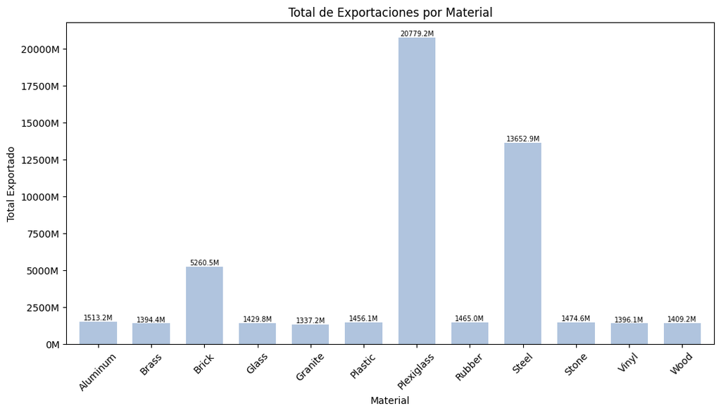

```python
# Total de exportaciones por material
materiales = export_df.columns.difference(['distributor_id'])
materiales_total = export_df[materiales].sum()

# El material con el valor total más alto
material_mas_exportado = materiales_total.idxmax()
material_mas_exportado_valor = materiales_total.max()

# El material con el valor total más bajo
material_menos_exportado = materiales_total.idxmin()
material_menos_exportado_valor = materiales_total.min()


print(f'\n\nEl material que más se exportó es {material_mas_exportado} con un total de ${material_mas_exportado_valor:.0f}')
print(f'\nEl material que menos se exportó es {material_menos_exportado} con un total de ${material_menos_exportado_valor:.0f}\n\n')



# Gráfico de barras para mostrar las exportaciones totales por material
plt.figure(figsize=(12, 6))
ax=materiales_total.plot(kind='bar', color='#B0C4DE',width=0.7)
plt.title('Total de Exportaciones por Material')
plt.xlabel('Material')
plt.ylabel('Total Exportado')
plt.xticks(rotation=45)

# Modificación de las unidades
ax.yaxis.set_major_formatter(mticker.FuncFormatter(lambda x, _: f'{int(x / 1000000)}M'))

# Añadir etiquetas en las barras
for bar in ax.patches:
    bar_x = bar.get_x() + bar.get_width() / 2
    bar_height = bar.get_height()
    ax.text(bar_x, bar_height + 5,f'{bar_height / 1000000:.1f}M', ha='center', va='bottom',fontsize=7)

plt.show()
```

## **Material con más y menos ventas**

```
El material que más se vendió es Plexiglass con un total de $25974040669

El material que menos se vendió es Steel con un total de $58458
```

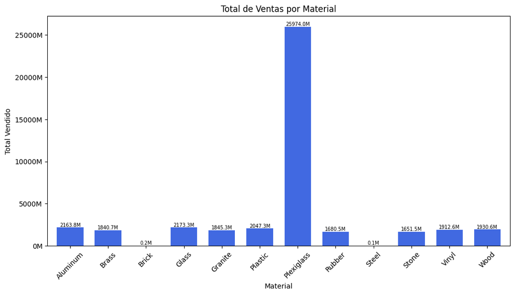

```python
# Obtención del material más vendido
materiales_vendidos = sales_df.columns.difference(['distributor_id'])
materiales_vendidos_total = sales_df[materiales].sum()
material_mas_vendido = materiales_vendidos_total.idxmax()
material_mas_vendido_valor = materiales_vendidos_total.max()

print(f'\n\nEl material que más se vendió es {material_mas_vendido} con un total de ${material_mas_vendido_valor:.0f}')
# Opción salida de texto en negrita: display(Markdown(f'**El material que más se vendió es {material_mas_vendido} con un total de ${material_mas_vendido_valor:.0f}**'))

# Obtención del material menos vendido
materiales_menos_vendidos = sales_df.columns.difference(['distributor_id'])
materiales_menos_vendidos_total = sales_df[materiales].sum()
menos_vendido = materiales_menos_vendidos_total.idxmin()
menos_vendido_valor = materiales_menos_vendidos_total.min()

print(f'\nEl material que menos se vendió es {menos_vendido} con un total de ${menos_vendido_valor:.0f}\n\n')
# Opción salida de texto en negrita: display(Markdown(f'**El material que menos se vendió es {menos_vendido} con un total de ${menos_vendido_valor:.0f}**'))


# Gráfico para mostrar el total de ventas por material
plt.figure(figsize=(12, 6))
axx=materiales_vendidos_total.plot(kind='bar',color="#4169E1",width=0.7)
plt.title('Total de Ventas por Material')
plt.xlabel('Material')
plt.ylabel('Total Vendido')
plt.xticks(rotation=45)

# Modificación de las unidades
axx.yaxis.set_major_formatter(mticker.FuncFormatter(lambda x, _: f'{int(x / 1000000)}M'))

# Añadir etiquetas en las barras
for bar in axx.patches:
    bar_x = bar.get_x() + bar.get_width() / 2
    bar_height = bar.get_height()
    axx.text(bar_x, bar_height + 5,f'{bar_height / 1000000:.1f}M', ha='center', va='bottom',fontsize=7)

plt.show()
```

## **Distribuidor con más y menos exportaciones**

```
El distribuidor que exportó más es "Brekke-Stiedemann" (id 1183) con un total de $12633899995

El distribuidor que exportó menos es "Keebler, Deckow and Watsica" (id 715) con un total de $319980088
```

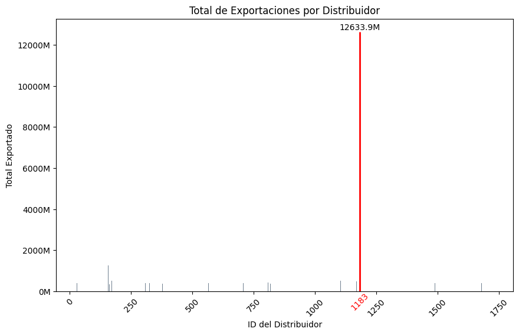

```python
# Generación de una copia del df para no modificar el original
export_df1=export_df.copy()

export_df1['total_export'] = export_df1.iloc[:, 1:].sum(axis=1)

# Obtención del distribuidor con más exportaciones
distribuidor_top = export_df1.loc[export_df1['total_export'].idxmax(), 'distributor_id']
total_exportado = export_df1['total_export'].max()
distribuidor_top_nombre = distributors_df.loc[distributors_df['distributor_id'] == distribuidor_top, 'distributor'].values[0]

print(f'\n\nEl distribuidor que exportó más es "{distribuidor_top_nombre}" (id {distribuidor_top}) con un total de ${total_exportado:.0f}\n')
# Opción texto en negrita: display(Markdown(f'**El distribuidor que exportó más es "{distribuidor_top_nombre}" (id {distribuidor_top}) con un total de ${total_exportado:.0f}**'))

# Obtención del distribuidor con menos exportaciones
distribuidor_bajo = export_df1.loc[export_df1['total_export'].idxmin(), 'distributor_id']
total_exportado_bajo = export_df1['total_export'].min()
distribuidor_nombre_bajo = distributors_df.loc[distributors_df['distributor_id'] == distribuidor_bajo, 'distributor'].values[0]

print(f'El distribuidor que exportó menos es "{distribuidor_nombre_bajo}" (id {distribuidor_bajo}) con un total de ${total_exportado_bajo:.0f}\n\n')
# Opción texto en negrita: display(Markdown(f'**El distribuidor que exportó menos es "{distribuidor_nombre_bajo}" (id {distribuidor_bajo}) con un total de ${total_exportado_bajo:.0f}**'))

# Gráfico de barras que muestra las exportaciones totales de cada distribuidor
plt.figure(figsize=(10, 6))
bars = plt.bar(export_df1['distributor_id'], export_df1['total_export'], color='#708090')

plt.title('Total de Exportaciones por Distribuidor')
plt.xlabel('ID del Distribuidor')
plt.ylabel('Total Exportado')
plt.xticks(rotation=45)

plt.gca().yaxis.set_major_formatter(mticker.FuncFormatter(lambda x, _: f'{int(x / 1000000)}M'))

# Destaque del distribuidor que más exportó
for bar, distributor_id in zip(bars, export_df1['distributor_id']):
    if distributor_id == distribuidor_top:
        bar.set_color('#FF0000')
        bar.set_linewidth(2)
        # Etiqueta en el destaque
        bar_x = bar.get_x() + bar.get_width() / 2
        bar_height = bar.get_height()
        plt.text(bar_x, bar_height + 50000, f'{bar_height / 1000000:.1f}M', ha='center', va='bottom')
        # Etiqueta del distribuidor destacado sobre el eje
        plt.text(bar_x, -100000,
                 distributor_id,
                 ha='center', va='top', rotation=45, color='#FF0000')
plt.show()
```

## **Distribuidor con más y menos ventas**

```
El distribuidor que vendió más es "Tromp-Abshire" (id 1235) con un total de $5921945910

El distribuidor que vendió menos es "Langworth Group" (id 1104) con un total de $243275402
```

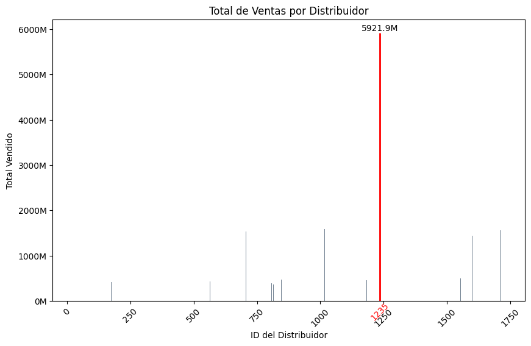

```python
# Generación de una copia del df para no modificar el original
sales_df1 = sales_df.copy()

sales_df1['total_sales'] = sales_df1.iloc[:, 1:].sum(axis=1)


# Obtención del distribuidor con más ventas
distribuidor_top_ventas = sales_df1.loc[sales_df1['total_sales'].idxmax(), 'distributor_id']
total_vendido = sales_df1['total_sales'].max()

distribuidor_nombre_ventas = distributors_df.loc[distributors_df['distributor_id'] == distribuidor_top_ventas, 'distributor'].values[0]
print(f'\n\nEl distribuidor que vendió más es "{distribuidor_nombre_ventas}" (id {distribuidor_top_ventas}) con un total de ${total_vendido:.0f}\n')


# Obtención del distribuidor con menos ventas
distribuidor_bajo_ventas = sales_df1.loc[sales_df1['total_sales'].idxmin(), 'distributor_id']
total_vendido_bajo = sales_df1['total_sales'].min()

distribuidor_nombre_bajo_ventas = distributors_df.loc[distributors_df['distributor_id'] == distribuidor_bajo_ventas, 'distributor'].values[0]
print(f'El distribuidor que vendió menos es "{distribuidor_nombre_bajo_ventas}" (id {distribuidor_bajo_ventas}) con un total de ${total_vendido_bajo:.0f}\n\n')

# Gráfico de total de ventas por distribuidor
plt.figure(figsize=(10, 6))
bars = plt.bar(sales_df1['distributor_id'], sales_df1['total_sales'], color='#708090')

plt.title('Total de Ventas por Distribuidor')
plt.xlabel('ID del Distribuidor')
plt.ylabel('Total Vendido')
plt.xticks(rotation=45)

plt.gca().yaxis.set_major_formatter(mticker.FuncFormatter(lambda x, _: f'{int(x / 1000000)}M'))

# Destaque del distribuidor que más exportó
for bar, distributor_id in zip(bars, sales_df1['distributor_id']):
    if distributor_id == distribuidor_top_ventas:
        bar.set_color('#FF0000')
        bar.set_linewidth(2)
        # Etiqueta en el destaque
        bar_x = bar.get_x() + bar.get_width() / 2
        bar_height = bar.get_height()
        plt.text(bar_x, bar_height + 50000, f'{bar_height / 1000000:.1f}M', ha='center', va='bottom')
        #  Etiqueta del distribuidor destacado sobre el eje
        plt.text(bar_x, -100000,
                 distributor_id,
                 ha='center', va='top', rotation=45, color='#FF0000')

plt.show()
```

## **Relación entre exportaciones y ventas de materiales**

### **Comparación entre total vendido y exportado por material**

```python
# Columnas df export
export_df.columns
```

```
Index(['distributor_id', 'Rubber', 'Brass', 'Vinyl', 'Granite', 'Stone',
       'Brick', 'Aluminum', 'Glass', 'Plexiglass', 'Steel', 'Wood', 'Plastic'],
      dtype='object')
```

```python
# Columnas df sales
sales_df.columns
```

```
Index(['distributor_id', 'Rubber', 'Brass', 'Vinyl', 'Granite', 'Stone',
       'Brick', 'Aluminum', 'Glass', 'Plexiglass', 'Steel', 'Wood', 'Plastic'],
      dtype='object')
```

```
      Material  Total Exportado  Total Vendido
0       Rubber     1.465042e+09   1.680454e+09
1        Brass     1.394439e+09   1.840659e+09
2        Vinyl     1.396050e+09   1.912589e+09
3      Granite     1.337170e+09   1.845295e+09
4        Stone     1.474571e+09   1.651519e+09
5        Brick     5.260549e+09   1.526580e+05
6     Aluminum     1.513170e+09   2.163833e+09
7        Glass     1.429787e+09   2.173276e+09
8   Plexiglass     2.077923e+10   2.597404e+10
9        Steel     1.365293e+10   5.845797e+04
10        Wood     1.409172e+09   1.930565e+09
11     Plastic     1.456144e+09   2.047338e+09



======================================================================================================================================
```

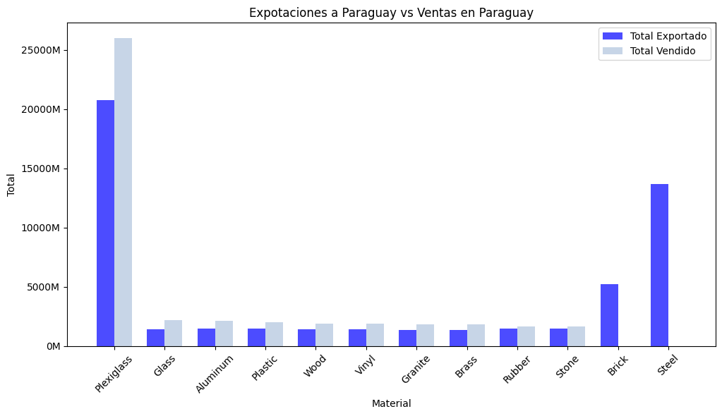

```python
totales_exportados = export_df.iloc[:, 1:].sum()
totales_vendidos = sales_df.iloc[:, 1:].sum()

# Generación de un nuevo df
totales_df = pd.DataFrame({
    'Material': totales_exportados.index,
    'Total Exportado': totales_exportados.values,
    'Total Vendido': totales_vendidos.values
})

# Reestablecimiento de índices para la obtención de una columna numerada
totales_df.reset_index(drop=True, inplace=True)

# Impresión de "totales df"
print(totales_df)
print('\n\n')
print("======================================================================================================================================")
print('\n\n')
totales_df = totales_df.sort_values(by='Total Vendido', ascending=False)

# Gráfico de comparación entre ventas y exportaciones
plt.figure(figsize=(10, 6))
bar_width = 0.35
x = range(len(totales_df))

# Barras para Total Exportado
bars1 = plt.bar(x, totales_df['Total Exportado'], width=bar_width, label='Total Exportado', color='blue', alpha=0.7)

# Barras para Total Vendido
bars2 = plt.bar([p + bar_width for p in x], totales_df['Total Vendido'], width=bar_width, label='Total Vendido', color='#B0C4DE', alpha=0.7)

plt.ylabel('Total')
plt.xlabel('Material')
plt.title('Expotaciones a Paraguay vs Ventas en Paraguay')

# Ajustar las etiquetas del eje X
plt.xticks([p + bar_width / 2 for p in x], totales_df['Material'], rotation=45)
plt.legend()
plt.tight_layout()

# Modificación de las unidades
plt.gca().yaxis.set_major_formatter(mticker.FuncFormatter(lambda x, _: f'{int(x / 1000000)}M'))

plt.show()
```

### **Materiales con sobreventas**

Para este cálculo se toma que la ganancia por producto = ventas - exportaciones

```python
# Incorporación de la columna "Ganancia" (sales_in_Paraguay-export_to_Paraguay)
totales_df['Ganancia'] = totales_df['Total Vendido'] - totales_df['Total Exportado']
```

```python
totales_df.columns
```

```
Index(['Material', 'Total Exportado', 'Total Vendido', 'Ganancia'], dtype='object')
```

```
      Material  Total Exportado  Total Vendido      Ganancia
8   Plexiglass     2.077923e+10   2.597404e+10  5.194808e+09
7        Glass     1.429787e+09   2.173276e+09  7.434891e+08
6     Aluminum     1.513170e+09   2.163833e+09  6.506629e+08
11     Plastic     1.456144e+09   2.047338e+09  5.911944e+08
10        Wood     1.409172e+09   1.930565e+09  5.213935e+08
2        Vinyl     1.396050e+09   1.912589e+09  5.165387e+08
3      Granite     1.337170e+09   1.845295e+09  5.081246e+08
1        Brass     1.394439e+09   1.840659e+09  4.462205e+08
0       Rubber     1.465042e+09   1.680454e+09  2.154115e+08
4        Stone     1.474571e+09   1.651519e+09  1.769485e+08



=================================================================================================================
```

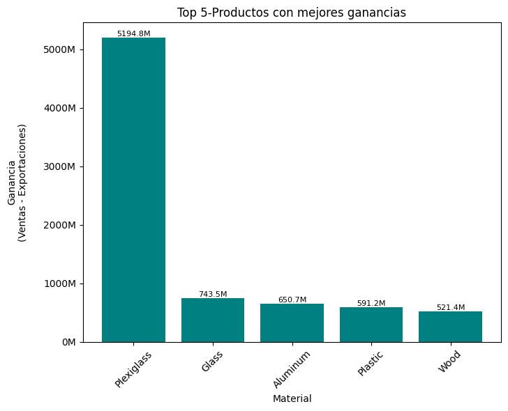

```python
# Filtración de productos con ganancias > 0
productos_ganancia = totales_df[totales_df['Ganancia'] > 0]

# Selección de los productos que dejan más ganancia
productos_top5 = productos_ganancia.sort_values('Ganancia', ascending=False).head(5)

print(productos_ganancia)
print('\n\n')
print("=================================================================================================================")
print('\n\n')

plt.figure(figsize=(7, 6))
plt.bar(productos_top5['Material'], productos_top5['Ganancia'], color='#008080')

plt.xlabel('Material')
plt.ylabel('Ganancia\n(Ventas - Exportaciones)\n')
plt.title('Top 5-Productos con mejores ganancias')
plt.axhline(0, color='black', linewidth=0.7)
plt.xticks(rotation=45)

plt.tight_layout()

# Modificación de las unidades
plt.gca().yaxis.set_major_formatter(mticker.FuncFormatter(lambda x, _: f'{int(x / 1000000)}M'))

# Añadir etiquetas en las barras
for bar in plt.gca().patches:
  bar_x = bar.get_x() + bar.get_width() / 2
  bar_height = bar.get_height()
  plt.text(bar_x, bar_height + 50000, f'{bar_height / 1000000:.1f}M', ha='center', va='bottom', fontsize=8)

plt.show()
```

# **CONCLUSIÓN**

En base en los datos analizados, se puede concluir que los materiales con mayores ganancias en Paraguay son Plexiglass, Glass, Aluminium, Plastic y Wood. Esta información puede verse claramente en el gráfico de comparación entre el dinero obtenido de las ventas y el dinero invertido en su exportación, son los que ocasionaron un importante margen de ganancia.

Plexiglass resultó ser el producto que mas dinero recaudó con sus ventas y también fue en el que más se invirtió con su exportación.

Así mismo, se puede visualizar que tanto steel como brick (dos de los tres materiales en los cuales se invirtió mas en su exportación), no lograron generar grandes ganancias con sus ventas. Esto provocó que se invirtiera mas de lo recaudado ocasionando una gran pérdida para la compañía, ya que en apariencia, resultan ser los productos menos atractivos para el mercado del país vecino.

Para el resto de los materiales, en general, se obtuvo una diferencia positiva entre ventas y exportaciones, lo cual compensaría un poco la mala decisión tomada en el caso del steel y del brick.

Se recomienda llevar a cabo un monitoreo continuo de las tendencias de ventas y las preferencias de los consumidores en Paraguay con el fin de ajustar las estrategias comerciales y de productos a las necesidades actuales.